# CS109 Final Project: Take One

[figure not shown]

The following notebook contains our original attempt to predict box office gross incomes using text sentiment analysis. It represents a large portion of our work and many hours of gathering, cleaning, and doing preliminary analysis on data, which is why we felt it necessary to include here. *This notebook contains our original line of thought and shows data science process.* We consider it a fail not in the sense that we were doing poor statistics, but in the sense that the data we obtained was not fit for the task at hand. Our preliminary analysis helped to illuminate this. We ultimately decided that we needed more data, and have included the process for obtaining and analysis this better data in another notebook, `Final_Project_vFINAL`. Please see that notebook after this one.

## Background & Motivation

Social media and entertainment are such pervasive parts of millennials' lives. We want to study the intersection of these two. Is it possible to predict box office success of film through sentiments expressed on social media? Stay tuned for more!

- CS109 Final Project Process Book
  - Milestone 1: Scrape and prepare data before thanksgiving
    - Scraping and cleaning Box Office Mojo
    - Loading and preparing IMDB review dataset
    - Loading and preparing AFINN dictionary
  - Milestone 2: Analysing and visualizing the data
    - Descriptive statistics
    - Analysis
    - Visualization
  - Milestone 3: Video and finishing touches
    - Screencast video
    - Website
    - Finishing touches

```python
%matplotlib inline
import numpy as np
import scipy as sp
import matplotlib as mpl
import matplotlib.cm as cm
import matplotlib.pyplot as plt
import pandas as pd
import time
import json
import statsmodels.api as sm
from statsmodels.formula.api import logit, glm, ols
pd.set_option('display.width', 500)
pd.set_option('display.max_columns', 100)
pd.set_option('display.notebook_repr_html', True)
import seaborn as sns
sns.set_style("whitegrid")
sns.set_context("poster")
import math
from sklearn.svm import LinearSVC
```

## Scrape Box Office Mojo and Prepare IMDB Data

For our project we will be using data from 3 different sources

**Box Office Mojo (BOM)** (http://www.boxofficemojo.com) is a website that aggregates, in a table, a list of all movies released in a year and attributes such as how much it grossed in the opening week, how much it grossed in total and how long it aired for

**Large Movie Review Dataset** (http://ai.stanford.edu/~amaas/data/sentiment/) is a polarized dataset of movie reviews from IMDB prepared by Maas et al from Stanford. The dataset contains 25,000 entries in the training set and 25,000 entries in the test set.

**AFINN-111 Dictionary** (http://www2.imm.dtu.dk/pubdb/views/publication_details.php?id=60100) is a dictionary list of 2477 english words and phrases rated for valence with an integer from -5 to 5. Originally prepared by Finn Årup Nielsen

In this first milestone, we will get all the data into a format that we can start running analysis on!

# Scraping and Loading Our Data

### Scraping Box Office Mojo

First we import the `requests` and `BeautifulSoup` libraries to make working with HTTP requests easier, and then easily transfer HTML content to Python data structures.

```python
from bs4 import BeautifulSoup
# The "requests" library makes working with HTTP requests easier
# than the built-in urllib libraries.
import requests
```

Secondly, we prepare the data frame `movie_df` to store the data that we will scrape from BOM. We give this dataframe 9 columns:

```
* ranking: the ranking of the movie in its release year by gross
* title: movie title
* gross: how much the movie grossed while in theatres
* Total_theaters: the total number of theaters that showed this movie
* opening_gross: how much the movie grossed in the opening weekend (Fri-Sun)
* opening_theaters: the total number of theaters that showed this movie in the opening weekend (Fri-Sun)
* open_date: date of opening
* close_date: date of closing
* year: year of release
```

```python
bom_df = pd.DataFrame(columns=['close_date', 'gross', 'open_date', 'opening_gross', 'opening_theaters','ranking','title','total_theaters','year'])
```

Now we write a function `rowInfoGrabber` that we will call in a loop over the table on the BOM webpage to grab the attributes and save them into the corresponding columns in `movie_df`.

```python
def rowInfoGrabber(r):
    info = []
    # Ranking
    info.append(int(r.find("font").get_text()))
    # Title
    info.append(r.find("a").get_text())
    # Gross
    info.append(int(r.find("td", attrs={"align":"right"}).find("b").get_text().strip("$").replace(",","")))
    '''
    For the next 3 categories, we need to deal with the 2000 Anomaly "Fantasia" where there are missing numbers.
    In this case I have chosen to replace the missing values 'N/A' with the values from 'Final Destination', which
    if right above it in the movie table and differs in gross income by about $1 million, which is a small
    difference. See the picture below for a snapshot of the anomaly in the movie table from 2000.
    '''
    # Total number of theaters
    if r.find_all("td",attrs={"align":"right"})[1].find("font").get_text().replace(",","") == 'N/A':
        info.append(2587)
    else:
        info.append(int(r.find_all("td",attrs={"align":"right"})[1].find("font").get_text().replace(",","")))
    # Opening Gross
    if r.find_all("td", attrs={"align":"right"})[2].find("font").get_text().strip("$").replace(",","") == 'N/A':
        info.append(10015822)
    else:
        info.append(int(r.find_all("td", attrs={"align":"right"})[2].find("font").get_text().strip("$").replace(",","")))
    # Opening Number of Theaters
    if r.find_all("td", attrs={"align":"right"})[3].find("font").get_text().replace(",","") == 'N/A':
        info.append(2587)
    else:
        info.append(int(r.find_all("td", attrs={"align":"right"})[3].find("font").get_text().replace(",","")))
    # Date of Opening
    info.append(r.find_all("td", attrs={"align":"right"})[4].find("a").get_text())
    # Date of Closing: Before 2002 they didn't have a "closing" date in their tables. We must account for this.
    if (len(r.find_all("td", attrs={"align":"right"})) <= 5):
        info.append('-')
    else:
        info.append(r.find_all("td", attrs={"align":"right"})[5].find("font").get_text())
    return info
```

[figure not shown]

```python
fields = ["ranking", "title", "gross", "total_theaters", "opening_gross", "opening_theaters", "open_date", "close_date"]
```

```python
%%time
years = [1990 + i for i in range(26)]
for year in years:
    pageText = requests.get("http://www.boxofficemojo.com/yearly/chart/?yr=%(yr)d&p=.htm" % {'yr':year})
    soup = BeautifulSoup(pageText.text, "html.parser")
    movieTable = soup.find("td", attrs={"colspan":"3"})
    movieRows = movieTable.find("table").find_all("tr")[2:102]
    movie_dicts = [dict(zip(fields, rowInfoGrabber(row))) for row in movieRows]
    year_df = pd.DataFrame(movie_dicts)
    year_df['year'] = year
    bom_df = bom_df.append(year_df, ignore_index=True)
    time.sleep(1)
```

```
CPU times: user 12.9 s, sys: 210 ms, total: 13.1 s
Wall time: 46.4 s
```

```python
print bom_df.shape
bom_df.head()
```

```
(2600, 9)
```

|  | close_date | gross | open_date | opening_gross | opening_theaters | ranking | title | total_theaters | year |
| --- | --- | --- | --- | --- | --- | --- | --- | --- | --- |
| 0 | - | 285761243 | 11/16 | 17081997 | 1202 | 1 | Home Alone | 2173 | 1990 |
| 1 | - | 217631306 | 7/13 | 12191540 | 1101 | 2 | Ghost | 1766 | 1990 |
| 2 | - | 184208848 | 11/9 | 598257 | 14 | 3 | Dances with Wolves | 1636 | 1990 |
| 3 | - | 178406268 | 3/23 | 11280591 | 1325 | 4 | Pretty Woman | 1811 | 1990 |
| 4 | - | 135265915 | 3/30 | 25398367 | 2006 | 5 | Teenage Mutant Ninja Turtles | 2377 | 1990 |

Because some films do not have a close date, we will have to be careful with the close date! Next, we combine the `close_date`, `open_date` and `year` columns into two columns `close_date` and `open_date` that are time series. This will make it easier for us to work with the data in the future.

```python
# splitting the close_date and open_date into the respective month and day
bom_df['close_month'] = bom_df['close_date'].map(lambda x: '0' if x=='-' else x[:x.find('/')])
bom_df['close_day'] = bom_df['close_date'].map(lambda x: '0' if x=='-' else x[x.find('/')+1:len(x)])
bom_df['open_month'] = bom_df['open_date'].map(lambda x: x[:x.find('/')])
bom_df['open_day'] = bom_df['open_date'].map(lambda x: x[x.find('/')+1:len(x)])

# dropping the old close_date and open_date
bom_df = bom_df.drop('close_date', 1)
bom_df = bom_df.drop('open_date', 1)

# creating an open_year by turning the year column into a string and getting rid of trailing bits
bom_df['open_year'] = bom_df.year.astype(str)
bom_df['open_year'] = bom_df.open_year.map(lambda x: x[:x.find('.')])

# creating a close_year column, by looking at whether the close month is earlier/later than the open month in the year
close_month = bom_df['close_month'].astype(int)
open_month = bom_df['open_month'].astype(int)
year = bom_df['year'].astype(int)
close_year=[]
for i in range (0, len(year)):
    if close_month[i] >= open_month[i]:
        close_year.append(year[i])
    else:
        close_year.append(year[i]+1)
bom_df['close_year'] = close_year
bom_df['close_year'] = bom_df['close_year'].astype(str)
```

```python
# making close_date and open_date by concatenating the year, month and day
import datetime
close_date = []
for index, row in bom_df.iterrows():
    if row.close_day != '0':
        close_date.append(datetime.datetime(int(row.close_year), int(row.close_month), int(row.close_day)))
    else:
        close_date.append(None)
bom_df['close_date'] = close_date

bom_df['open_date']=bom_df.open_year + '-' + bom_df.open_month + '-' + bom_df.open_day
bom_df['open_date']=bom_df['open_date'].apply(pd.datetools.parse)
```

Let's take a look at the data, now!

```python
bom_df.head()
```

|  | gross | opening_gross | opening_theaters | ranking | title | total_theaters | year | close_month | close_day | open_month | open_day | open_year | close_year | close_date | open_date |
| --- | --- | --- | --- | --- | --- | --- | --- | --- | --- | --- | --- | --- | --- | --- | --- |
| 0 | 285761243 | 17081997 | 1202 | 1 | Home Alone | 2173 | 1990 | 0 | 0 | 11 | 16 | 1990 | 1991 | None | 1990-11-16 |
| 1 | 217631306 | 12191540 | 1101 | 2 | Ghost | 1766 | 1990 | 0 | 0 | 7 | 13 | 1990 | 1991 | None | 1990-07-13 |
| 2 | 184208848 | 598257 | 14 | 3 | Dances with Wolves | 1636 | 1990 | 0 | 0 | 11 | 9 | 1990 | 1991 | None | 1990-11-09 |
| 3 | 178406268 | 11280591 | 1325 | 4 | Pretty Woman | 1811 | 1990 | 0 | 0 | 3 | 23 | 1990 | 1991 | None | 1990-03-23 |
| 4 | 135265915 | 25398367 | 2006 | 5 | Teenage Mutant Ninja Turtles | 2377 | 1990 | 0 | 0 | 3 | 30 | 1990 | 1991 | None | 1990-03-30 |

Let's take a look at if we can get the run times for each movie!

```python
run_time=[]
for index, row in bom_df.iterrows():
    if row.close_date != None:
        run_time.append(row['close_date']-row['open_date'])
    else:
        run_time.append('N/A')
```

Looks like the data is ready for us to use! Let's save this data so we're ready to use it next time.

```python
! pip install pymongo
```

```python
# Save the movie Dictionaries corresponding to each row of the BoxOfficeMojo table.
import json
import pymongo
from bson import json_util

# Make a dictionary out of the dataset for storage in JSON format.
movieSaved = {feature: bom_df[feature].values.tolist() for feature in bom_df.columns.values}
fp = open("allMovies.json","w")
json.dump(movieSaved, fp, default=json_util.default)
fp.close()
```

### Loading and preparing IMDB review dataset

We have cleaned up our IMDB review dataset in the ipython notebook `IMDB_reviews.ipynb`. From that notebook we have been able to save dictionaries of our data, which we will now call.

```python
with open("train_df_dict.json", "r") as fd:
    train_df_dict = json.load(fd)
with open("test_df_dict.json", "r") as fd:
    test_df_dict = json.load(fd)
```

```python
train_df = pd.DataFrame(train_df_dict)
test_df = pd.DataFrame(test_df_dict)
```

The Stanford group distinguishes between train and test because this was relevant for their project. This may prove to be useful later, so we will keep two separate dataframes. However, for our purposes at the moment, we can combine them since the BOM data will serve as our true data set.

```python
IMDB_df = train_df.append(test_df)
```

We want to figure out which movies from IMDB_df are also present in our BOM DF. So let's get all the movie titles in our BOM table.

```python
BOM_movie_list = bom_df.title.values.tolist()
```

Now let's create a mask over IMDB_df, the boolean values of which indicate whether or not a movie is in the BOM list.

```python
movie_mask = [(movie in BOM_movie_list) for movie in IMDB_df.movie_name]
```

```python
sum(movie_mask)
```

```
4111
```

We can now create our IMDB data frame with only those movies that also appear in the BOM tables from 1990 - 2015.

```python
IMDB_dftouse=IMDB_df[movie_mask]
```

Finally we want to save our dictionary of IMDB_dftouse into a JSON file for storage.

```python
IMDB_dftouse_dict = {feature: IMDB_dftouse[feature].values.tolist() for feature in IMDB_dftouse.columns.values}
fp = open("IMDB_dftouse_dict.json","w")
json.dump(IMDB_dftouse_dict, fp)
fp.close()
```

```python
# Reopen
with open("IMDB_dftouse_dict.json", "r") as fd:
    IMDB_dftouse_dict = json.load(fd)
IMDB_dftouse = pd.DataFrame(IMDB_dftouse_dict)
```

## Analyzing and Saving Review Attributes Using labMT Happiness Dictionary

Note: We originally intended to use the AFINN word list prepared by Finn Årup Nielsen to obtain word valences (http://www2.imm.dtu.dk/pubdb/views/publication_details.php?id=60100), but ultimately decided to use labMT.  
labMTs word list contains around 10,000 scored words, whereas AFINN's only contains 2477.

Now let's download labMT. The file contains a "happiness" value, and ranks words by their happiness. It also includes mean and standard deviation, Twitter rank and Google rank.

```python
url = 'http://www.plosone.org/article/fetchSingleRepresentation.action?uri=info:doi/10.1371/journal.pone.0026752.s001'
labmt = pd.read_csv(url, skiprows=2, sep='\t', index_col=0)
```

```python
labmt.head()
```

| word | happiness_rank | happiness_average | happiness_standard_deviation | twitter_rank | google_rank | nyt_rank | lyrics_rank |
| --- | --- | --- | --- | --- | --- | --- | --- |
| laughter | 1 | 8.50 | 0.9313 | 3600 | -- | -- | 1728 |
| happiness | 2 | 8.44 | 0.9723 | 1853 | 2458 | -- | 1230 |
| love | 3 | 8.42 | 1.1082 | 25 | 317 | 328 | 23 |
| happy | 4 | 8.30 | 0.9949 | 65 | 1372 | 1313 | 375 |
| laughed | 5 | 8.26 | 1.1572 | 3334 | 3542 | -- | 2332 |

Now let's create a happiness dictionary of (word, valence) pairs where each valence is that word's original valence minus the average valence.

```python
average = labmt.happiness_average.mean()
happiness = (labmt.happiness_average - average).to_dict()
```

```python
print "Score(happy): ", happiness['happy']
print "Score(miserable): ", happiness['miserable']
print "Best score: ", max(happiness.values())
print "Worst score: ", min(happiness.values())
```

```
Score(happy):  2.92476032088
Score(miserable):  -2.83523967912
Best score:  3.12476032088
Worst score:  -4.07523967912
```

```python
# Save to disc
# fp = open("happiness.json","w")
# json.dump(happiness, fp)
# fp.close()
```

```python
# Reopen
with open("happiness.json", "r") as fp:
    happiness = json.load(fp)
```

Now let's collect several attributes from a given review's text body, and save all valuable information into a new data frame. First we define a function that removes stop words (all non important words from a valence perspective) from a text body.

```python
from sklearn.feature_extraction import text
stopwords = text.ENGLISH_STOP_WORDS
punctuation = list('.,;:!?()[]{}`''\"@#$%^&*+-|-=~_')

def removeStopWords(text, stopwords = stopwords):
    new_text = ""
    for word in text.split():
        if word not in stopwords:
            while len(word) != 0 and word[-1] in punctuation:
                word = word[:len(word)-1]
            new_text += word + ' '
    return new_text
```

Now we'll write a function that returns total happiness, average happiness, total scorable words, and percentage of scorable words in a given review text.

```python
'''
Name: getValenceInfo()
Inputs: review text, dictionary of happiness
Returns: a 4-tuple of (happiness total, happiness average, total # of scorable words, % of scorable words)
'''
def getValenceInfo(text, valenceDict):
    total_words = len(text.split())
    happiness_total, count_relevant = 0, 0
    for word in text.split():
        if word in valenceDict.keys():
            count_relevant += 1
            happiness_total += valenceDict[word]
    if count_relevant != 0:
        avg_valence = 1.*happiness_total/count_relevant
    else:
        avg_valence = 0
    return happiness_total, avg_valence, total_words, 1.*count_relevant / total_words
```

Now we'll write a function that, given a data frame, returns a new data frame with the concatenation of valence (happiness) info in 4 new columns: valence sum, valence average, # of scorable words, % of scorable words.

```python
'''
Name: getAllInfo
Input: data frame, happiness dictionary, list of stop words
Returns: a new data frame with 4 new columns: valence_sum, valence_avg, n_scorables, pct_scorables
'''
def getAllInfo(df, valenceDict, stopwords):
    valence_suml, valence_avgl, review_lenl, review_fractionl = [], [], [], []
    for i, row in df.iterrows():
        cleaned_review = removeStopWords(row['text'], stopwords)
        valence_sum, valence_avg, review_len, review_fraction = getValenceInfo(cleaned_review, valenceDict)
        valence_suml.append(valence_sum)
        valence_avgl.append(valence_avg)
        review_lenl.append(review_len)
        review_fractionl.append(review_fraction)
    conc = pd.DataFrame({'valence_sum': valence_suml, 'valence_avg':valence_avgl ,'n_scorables': review_lenl,
                         'pct_scorables': review_fractionl})
    return pd.concat([df, conc], axis=1)
```

Now let's create a new dataframe `valence_df` with the valence statistics run on our IMDB_df. This code takes a few minutes to run.

```python
%%time
valence_df = getAllInfo(IMDB_dftouse, happiness, stopwords)
```

[output not shown]

```python
valence_df.head()
```

[output not shown]

Let's convert True/False to 1/0. It is needed to make valence_df JSON serializable, also better practice.

```python
valence_df.positive = 1.0*valence_df.positive
```

```python
# Save to disc
fp = open("valence_df_dict.json","w")
json.dump(valence_df.to_dict(), fp)
fp.close()
```

```python
# Reopen
with open("valence_df_dict.json", "r") as fp:
    valence_df_dict = json.load(fp)
valence_df = pd.DataFrame(valence_df_dict)
```

## Collecting Valence Statistics and Adjusting for Inflation

Let's see how well our valence summaries correlate with the reviews stars. This will serve as a sanity check to see if our valence estimates are working.

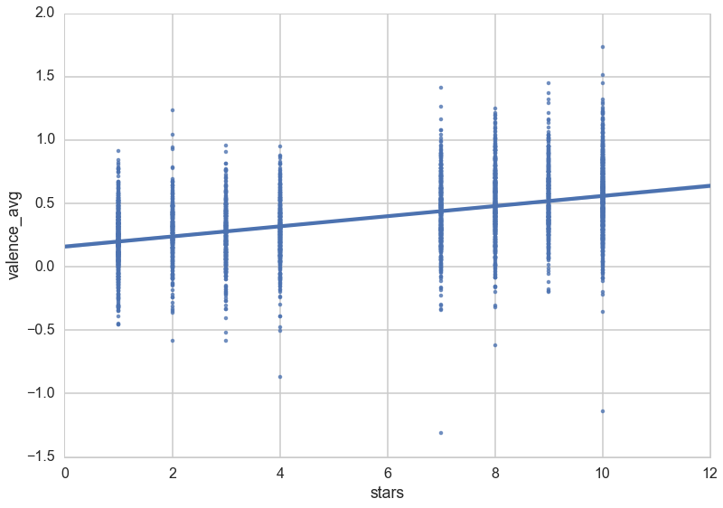

```python
stars_val_avg = ols('stars ~ valence_avg',valence_df).fit()
stars_val_avg.summary()
sns.regplot(y="valence_avg", x="stars", data=valence_df)
```

Yes it does, to some extent. The explanatory power is not high though.

Now, let's have a look at the valences of our positive and negative reviews and see how each is distributed to get a better sense of our data.

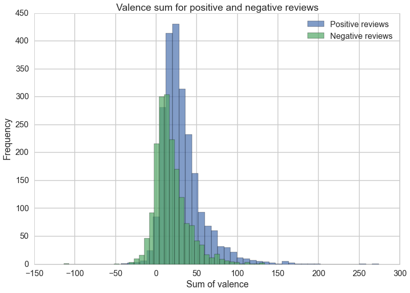

```python
graph_val_avg = plt.hist(valence_df.valence_sum[valence_df.stars >=7],bins=40,alpha=0.7,label="Positive reviews")
graph_val_avg = plt.hist(valence_df.valence_sum[valence_df.stars <=4],bins=40,alpha=0.7,label="Negative reviews")
graph_val_avg = plt.title("Valence sum for positive and negative reviews")
graph_val_avg = plt.xlabel("Sum of valence")
graph_val_avg = plt.ylabel("Frequency")
graph_val_avg = plt.legend(loc='upper right')
```

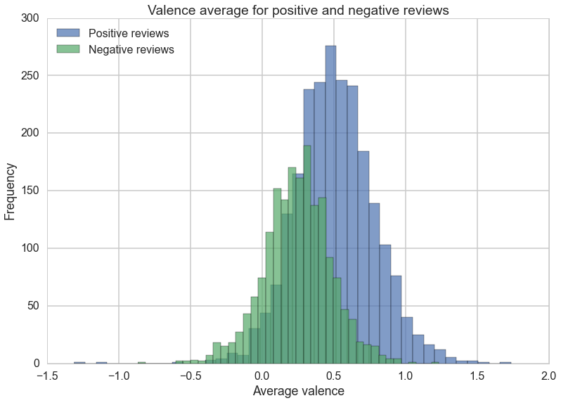

```python
graph_val_avg = plt.hist(valence_df.valence_avg[valence_df.stars >=7],bins=40,alpha=0.7,label="Positive reviews")
graph_val_avg = plt.hist(valence_df.valence_avg[valence_df.stars <=4],bins=40,alpha=0.7,label="Negative reviews")
graph_val_avg = plt.title("Valence average for positive and negative reviews")
graph_val_avg = plt.xlabel("Average valence")
graph_val_avg = plt.ylabel("Frequency")
graph23 = plt.legend(loc='upper left')
```

```python
with open("allMovies.json", "r") as fd:
    bom_df = json.load(fd)
    bom_df = pd.DataFrame(bom_df)
```

```python
bom_df[2572:2577]
```

|  | close_date | close_day | close_month | close_year | gross | open_date | open_day | open_month | open_year | opening_gross | opening_theaters | ranking | title | total_theaters | year |
| --- | --- | --- | --- | --- | --- | --- | --- | --- | --- | --- | --- | --- | --- | --- | --- |
| 2572 | {u'$date': 1446076800000} | 29 | 10 | 2015 | 27740955 | 1440115200000000000 | 21 | 8 | 2015 | 10542116 | 2766 | 73 | Sinister 2 | 2799 | 2015 |
| 2573 | {u'$date': 1448496000000} | 26 | 11 | 2015 | 27288872 | 1440547200000000000 | 26 | 8 | 2015 | 8111264 | 3355 | 74 | No Escape | 3415 | 2015 |
| 2574 | None | 0 | 0 | 2016 | 27121602 | 1445558400000000000 | 23 | 10 | 2015 | 10812861 | 3082 | 75 | The Last Witch Hunter | 3082 | 2015 |
| 2575 | {u'$date': 1444521600000} | 11 | 10 | 2015 | 26822144 | 1438905600000000000 | 7 | 8 | 2015 | 6610961 | 1603 | 76 | Ricki and the Flash | 2064 | 2015 |
| 2576 | {u'$date': 1426723200000} | 19 | 3 | 2015 | 26501323 | 1420156800000000000 | 2 | 1 | 2015 | 15027415 | 2602 | 77 | The Woman in Black 2: Angel of Death | 2602 | 2015 |

Let's make the dataframe a little bit cleaner.

```python
# making close_date and open_date by concatenating the year, month and day
import datetime
close_date = []
for index, row in bom_df.iterrows():
    if row.close_day != '0':
        close_date.append(datetime.datetime(int(row.close_year), int(row.close_month), int(row.close_day)))
    else:
        close_date.append(None)
bom_df['close_date'] = close_date

bom_df['open_date']=bom_df.open_year + '-' + bom_df.open_month + '-' + bom_df.open_day
bom_df['open_date']=bom_df['open_date'].apply(pd.datetools.parse)

# dropping unnecessary columns
bom_df = bom_df.drop('close_day', 1)
bom_df = bom_df.drop('close_month', 1)
bom_df = bom_df.drop('open_day', 1)
bom_df = bom_df.drop('open_month', 1)
```

Great! Let's take a look at all the dataframes we've created

```python
bom_df.head()
```

|  | close_date | close_year | gross | open_date | open_year | opening_gross | opening_theaters | ranking | title | total_theaters | year |
| --- | --- | --- | --- | --- | --- | --- | --- | --- | --- | --- | --- |
| 0 | None | 1991 | 285761243 | 1990-11-16 | 1990 | 17081997 | 1202 | 1 | Home Alone | 2173 | 1990 |
| 1 | None | 1991 | 217631306 | 1990-07-13 | 1990 | 12191540 | 1101 | 2 | Ghost | 1766 | 1990 |
| 2 | None | 1991 | 184208848 | 1990-11-09 | 1990 | 598257 | 14 | 3 | Dances with Wolves | 1636 | 1990 |
| 3 | None | 1991 | 178406268 | 1990-03-23 | 1990 | 11280591 | 1325 | 4 | Pretty Woman | 1811 | 1990 |
| 4 | None | 1991 | 135265915 | 1990-03-30 | 1990 | 25398367 | 2006 | 5 | Teenage Mutant Ninja Turtles | 2377 | 1990 |
| 5 | None | 1991 | 122012643 | 1990-03-02 | 1990 | 17161835 | 1225 | 6 | The Hunt for Red October | 1817 | 1990 |
| 6 | None | 1991 | 119394840 | 1990-06-01 | 1990 | 25533700 | 2060 | 7 | Total Recall | 2131 | 1990 |
| 7 | None | 1991 | 117540947 | 1990-07-06 | 1990 | 21744661 | 2507 | 8 | Die Hard 2: Die Harder | 2507 | 1990 |
| 8 | None | 1991 | 103738726 | 1990-06-15 | 1990 | 22543911 | 2332 | 9 | Dick Tracy | 2332 | 1990 |
| 9 | None | 1991 | 91457688 | 1990-12-22 | 1990 | 7918560 | 1833 | 10 | Kindergarten Cop | 1937 | 1990 |
| 10 | None | 1991 | 87727583 | 1990-05-25 | 1990 | 19089645 | 2019 | 11 | Back to the Future Part III | 2070 | 1990 |
| 11 | None | 1991 | 86303188 | 1990-07-27 | 1990 | 11718981 | 1349 | 12 | Presumed Innocent | 1451 | 1990 |
| 12 | None | 1991 | 82670733 | 1990-06-29 | 1990 | 15490445 | 2307 | 13 | Days of Thunder | 2307 | 1990 |
| 13 | None | 1991 | 80818974 | 1990-06-08 | 1990 | 19475559 | 2721 | 14 | Another 48 HRS. | 2721 | 1990 |
| 14 | None | 1991 | 71609321 | 1990-11-21 | 1990 | 13774642 | 1281 | 15 | Three Men and a Little Lady | 1614 | 1990 |
| 15 | None | 1991 | 70978012 | 1990-05-18 | 1990 | 15338160 | 1944 | 16 | Bird on a Wire | 2008 | 1990 |
| 16 | None | 1991 | 66666062 | 1990-12-25 | 1990 | 19558558 | 1901 | 17 | The Godfather Part III | 1922 | 1990 |
| 17 | None | 1991 | 61489265 | 1990-08-10 | 1990 | 10034685 | 1319 | 18 | Flatliners | 1483 | 1990 |
| 18 | None | 1991 | 61276872 | 1990-11-30 | 1990 | 10076834 | 1244 | 19 | Misery | 1370 | 1990 |
| 19 | None | 1991 | 56362352 | 1990-12-07 | 1990 | 159622 | 2 | 20 | Edward Scissorhands | 1372 | 1990 |
| 20 | None | 1991 | 53470891 | 1990-07-27 | 1990 | 10026900 | 1714 | 21 | Problem Child | 1769 | 1990 |
| 21 | None | 1991 | 53208180 | 1990-07-20 | 1990 | 8045760 | 1479 | 22 | Arachnophobia | 2005 | 1990 |
| 22 | None | 1991 | 52096475 | 1990-12-22 | 1990 | 417076 | 12 | 23 | Awakenings | 1330 | 1990 |
| 23 | None | 1991 | 47789074 | 1990-12-14 | 1990 | 8100640 | 1576 | 24 | Look Who's Talking Too | 1647 | 1990 |
| 24 | None | 1991 | 47410827 | 1990-02-09 | 1990 | 9213631 | 1301 | 25 | Hard to Kill | 1508 | 1990 |
| 25 | None | 1991 | 46836214 | 1990-09-19 | 1990 | 6368901 | 1070 | 26 | Goodfellas | 1328 | 1990 |
| 26 | None | 1991 | 46044396 | 1990-10-05 | 1990 | 11790047 | 1968 | 27 | Marked for Death | 1974 | 1990 |
| 27 | None | 1991 | 45681173 | 1990-06-22 | 1990 | 14145411 | 1768 | 28 | Robocop 2 | 1806 | 1990 |
| 28 | None | 1991 | 44645619 | 1990-07-13 | 1990 | 7708029 | 1901 | 29 | The Jungle Book (re-issue) (1990) | 1923 | 1990 |
| 29 | None | 1991 | 44143410 | 1990-08-03 | 1990 | 8017438 | 1770 | 30 | Young Guns II | 1770 | 1990 |
| ... | ... | ... | ... | ... | ... | ... | ... | ... | ... | ... | ... |
| 2570 | None | 2016 | 31090320 | 2015-10-16 | 2015 | 13143310 | 2984 | 71 | Crimson Peak | 2991 | 2015 |
| 2571 | None | 2016 | 29476394 | 2015-09-02 | 2015 | 8246267 | 1960 | 72 | A Walk in the Woods | 2158 | 2015 |
| 2572 | 2015-10-29 00:00:00 | 2015 | 27740955 | 2015-08-21 | 2015 | 10542116 | 2766 | 73 | Sinister 2 | 2799 | 2015 |
| 2573 | 2015-11-26 00:00:00 | 2015 | 27288872 | 2015-08-26 | 2015 | 8111264 | 3355 | 74 | No Escape | 3415 | 2015 |
| 2574 | None | 2016 | 27121602 | 2015-10-23 | 2015 | 10812861 | 3082 | 75 | The Last Witch Hunter | 3082 | 2015 |
| 2575 | 2015-10-11 00:00:00 | 2015 | 26822144 | 2015-08-07 | 2015 | 6610961 | 1603 | 76 | Ricki and the Flash | 2064 | 2015 |
| 2576 | 2015-03-19 00:00:00 | 2015 | 26501323 | 2015-01-02 | 2015 | 15027415 | 2602 | 77 | The Woman in Black 2: Angel of Death | 2602 | 2015 |
| 2577 | 2015-05-07 00:00:00 | 2015 | 26461644 | 2015-03-13 | 2015 | 11012305 | 3171 | 78 | Run All Night | 3171 | 2015 |
| 2578 | 2015-06-11 00:00:00 | 2015 | 25801047 | 2015-02-27 | 2015 | 10203437 | 2666 | 79 | The Lazarus Effect | 2666 | 2015 |
| 2579 | 2015-09-03 00:00:00 | 2015 | 25442958 | 2015-04-10 | 2015 | 237264 | 4 | 80 | Ex Machina | 2004 | 2015 |
| 2580 | None | 2016 | 22822987 | 2015-11-13 | 2015 | 8317545 | 2603 | 81 | Love the Coopers | 2603 | 2015 |
| 2581 | 2015-09-17 00:00:00 | 2015 | 22764410 | 2015-07-10 | 2015 | 9808463 | 2720 | 82 | The Gallows | 2720 | 2015 |
| 2582 | 2015-10-15 00:00:00 | 2015 | 22467450 | 2015-08-21 | 2015 | 8326530 | 3261 | 83 | Hitman: Agent 47 | 3273 | 2015 |
| 2583 | 2015-03-26 00:00:00 | 2015 | 22348241 | 2015-01-30 | 2015 | 8310252 | 2893 | 84 | Project Almanac | 2900 | 2015 |
| 2584 | 2015-05-14 00:00:00 | 2015 | 21571189 | 2015-01-30 | 2015 | 6213362 | 1823 | 85 | Black or White | 1823 | 2015 |
| 2585 | 2015-07-30 00:00:00 | 2015 | 21067116 | 2015-05-29 | 2015 | 9670235 | 2815 | 86 | Aloha | 2815 | 2015 |
| 2586 | 2015-10-22 00:00:00 | 2015 | 19375982 | 2015-08-05 | 2015 | 4038962 | 2320 | 87 | Shaun the Sheep Movie | 2360 | 2015 |
| 2587 | 2015-05-21 00:00:00 | 2015 | 18754371 | 2015-01-16 | 2015 | 197000 | 12 | 88 | Still Alice | 1318 | 2015 |
| 2588 | None | 2016 | 18300124 | 2015-10-23 | 2015 | 8070493 | 1656 | 89 | Paranormal Activity: The Ghost Dimension | 1656 | 2015 |
| 2589 | None | 2016 | 17753943 | 2015-10-09 | 2015 | 521522 | 4 | 90 | Steve Jobs | 2493 | 2015 |
| 2590 | 2015-11-05 00:00:00 | 2015 | 17737646 | 2015-07-17 | 2015 | 2434908 | 361 | 91 | Mr. Holmes | 898 | 2015 |
| 2591 | 2015-09-17 00:00:00 | 2015 | 17506470 | 2015-06-19 | 2015 | 6100010 | 2002 | 92 | Dope | 2002 | 2015 |
| 2592 | None | 2016 | 17402274 | 2015-11-20 | 2015 | 6652996 | 2392 | 93 | The Secret in their Eyes (2015) | 2392 | 2015 |
| 2593 | None | 2016 | 17265460 | 2015-12-04 | 2015 | 16293325 | 2902 | 94 | Krampus | 2902 | 2015 |
| 2594 | 2015-03-19 00:00:00 | 2015 | 17223265 | 2015-02-06 | 2015 | 7217640 | 2875 | 95 | Seventh Son | 2875 | 2015 |
| 2595 | None | 2016 | 16792305 | 2015-11-06 | 2015 | 295009 | 5 | 96 | Spotlight | 1089 | 2015 |
| 2596 | 2015-07-23 00:00:00 | 2015 | 16432322 | 2015-04-17 | 2015 | 4577861 | 2012 | 97 | Monkey Kingdom | 2012 | 2015 |
| 2597 | 2015-11-19 00:00:00 | 2015 | 16029670 | 2015-09-04 | 2015 | 7355622 | 3434 | 98 | The Transporter Refueled | 3434 | 2015 |
| 2598 | 2015-06-25 00:00:00 | 2015 | 14674076 | 2015-03-13 | 2015 | 160089 | 4 | 99 | It Follows | 1655 | 2015 |
| 2599 | 2015-10-08 00:00:00 | 2015 | 14440985 | 2015-08-21 | 2015 | 5454284 | 2778 | 100 | American Ultra | 2778 | 2015 |

2600 rows × 11 columns

Now, we want to make a new dataframe `flattened_df` that we can use to run our regressions on. This dataframe will include all the columns in `movie_df` and the extra columns

- number of reviews for the movie in IMDB_df
- average stars from the reviews
- overall ranking

```python
# set index to title
indexed_df = bom_df.set_index("title")
```

```python
# use groupby to get the review_count, star_avg, valence_avg, valence_sum, pct_scorables, n_scorables
gold = valence_df.groupby("movie_name")
n_scorables = gold.n_scorables.mean()
pct_scorables = gold.pct_scorables.mean()
review_count = gold.movie_name.count()
star_avg = gold.stars.mean()
positive = gold.positive.mean()
valence_avg = gold.valence_avg.mean()
valence_sum = gold.valence_sum.mean()
```

```python
# concatenate the two dfs into our final dataframe flattened_df
flattened_df = pd.concat([indexed_df, review_count], axis=1, join_axes=[indexed_df.index])
flattened_df.rename(columns={'movie_name': 'review_count'}, inplace=True)
flattened_df = pd.concat([flattened_df, star_avg], axis=1, join_axes=[indexed_df.index])
flattened_df.rename(columns={'stars': 'star_avg'}, inplace=True)
flattened_df = pd.concat([flattened_df, positive], axis=1, join_axes=[indexed_df.index])

flattened_df = pd.concat([flattened_df, valence_avg], axis=1, join_axes=[indexed_df.index])
# flattened_df.rename(columns={'movie_name': 'review_count'}, inplace=True)
flattened_df = pd.concat([flattened_df, valence_sum], axis=1, join_axes=[indexed_df.index])
# flattened_df.rename(columns={'movie_name': 'review_count'}, inplace=True)

flattened_df = pd.concat([flattened_df, n_scorables], axis=1, join_axes=[indexed_df.index])

flattened_df = pd.concat([flattened_df, pct_scorables], axis=1, join_axes=[indexed_df.index])


# flattened_df.rename(columns={'absolute_stars': 'abs_star_avg'}, inplace=True)
```

```python
flattened_df.head()
```

| title | close_date | close_year | gross | open_date | open_year | opening_gross | opening_theaters | ranking | total_theaters | year | review_count | star_avg | positive | valence_avg | valence_sum | n_scorables | pct_scorables |
| --- | --- | --- | --- | --- | --- | --- | --- | --- | --- | --- | --- | --- | --- | --- | --- | --- | --- |
| Home Alone | None | 1991 | 285761243 | 1990-11-16 | 1990 | 17081997 | 1202 | 1 | 2173 | 1990 | NaN | NaN | NaN | NaN | NaN | NaN | NaN |
| Ghost | None | 1991 | 217631306 | 1990-07-13 | 1990 | 12191540 | 1101 | 2 | 1766 | 1990 | NaN | NaN | NaN | NaN | NaN | NaN | NaN |
| Dances with Wolves | None | 1991 | 184208848 | 1990-11-09 | 1990 | 598257 | 14 | 3 | 1636 | 1990 | NaN | NaN | NaN | NaN | NaN | NaN | NaN |
| Pretty Woman | None | 1991 | 178406268 | 1990-03-23 | 1990 | 11280591 | 1325 | 4 | 1811 | 1990 | 2 | 1 | 0 | 0.407409 | 84.055626 | 338 | 0.613324 |
| Teenage Mutant Ninja Turtles | None | 1991 | 135265915 | 1990-03-30 | 1990 | 25398367 | 2006 | 5 | 2377 | 1990 | NaN | NaN | NaN | NaN | NaN | NaN | NaN |

Let's create a new column for the absolute value of the valence averages of the reviews for a particular movie. This will eventually test the hypothesis of whether or not polarizing movies make a lot of money.

```python
valence_df['abs_valence_avg'] = np.abs(valence_df['valence_avg']-np.mean(flattened_df['valence_avg']))
abs_valence_avg = gold.abs_valence_avg.mean()
flattened_df = pd.concat([flattened_df, abs_valence_avg], axis=1, join_axes=[indexed_df.index])
```

```python
flattened_df.head()
```

| title | close_date | close_year | gross | open_date | open_year | opening_gross | opening_theaters | ranking | total_theaters | year | review_count | star_avg | positive | valence_avg | valence_sum | n_scorables | pct_scorables | abs_valence_avg |
| --- | --- | --- | --- | --- | --- | --- | --- | --- | --- | --- | --- | --- | --- | --- | --- | --- | --- | --- |
| Home Alone | None | 1991 | 285761243 | 1990-11-16 | 1990 | 17081997 | 1202 | 1 | 2173 | 1990 | NaN | NaN | NaN | NaN | NaN | NaN | NaN | NaN |
| Ghost | None | 1991 | 217631306 | 1990-07-13 | 1990 | 12191540 | 1101 | 2 | 1766 | 1990 | NaN | NaN | NaN | NaN | NaN | NaN | NaN | NaN |
| Dances with Wolves | None | 1991 | 184208848 | 1990-11-09 | 1990 | 598257 | 14 | 3 | 1636 | 1990 | NaN | NaN | NaN | NaN | NaN | NaN | NaN | NaN |
| Pretty Woman | None | 1991 | 178406268 | 1990-03-23 | 1990 | 11280591 | 1325 | 4 | 1811 | 1990 | 2 | 1 | 0 | 0.407409 | 84.055626 | 338 | 0.613324 | 0.129283 |
| Teenage Mutant Ninja Turtles | None | 1991 | 135265915 | 1990-03-30 | 1990 | 25398367 | 2006 | 5 | 2377 | 1990 | NaN | NaN | NaN | NaN | NaN | NaN | NaN | NaN |

Now let's take only those movies that appear in the IMDB data set, i.e. those that have a review count.

```python
flattened_df = flattened_df[~flattened_df['review_count'].map(np.isnan)]
print "Num. overlapping movies: ", flattened_df.shape[0]
```

[output not shown]

### Adjusting for Inflation

The purchasing power of individuals change over time due to the changes in the value of money. Thus, to compare the true value of movies that came out in different years, we need yearly U.S. inflation data.

For instance, Avatar looks like highest grossing movie of all time, but when adjusted for inflation, turns out it's actually Gone with the Wind.

Hence, we need to adjust the gross incomes of movies for inflation over the past 26 years to get better insight into how successful they truly were in the box office.

```python
inflation = pd.read_csv("inf.csv")
```

```python
years_90 = range(1990,2015)
infdict = {}
infindex, infvalue = 0, 1

testlist = []
for row in inflation.values:
    currentval = 1 + (row[1]/100)
    cuminf = infvalue*currentval
    infdict[years_90[infindex]] = cuminf
    infindex += 1
    infvalue = cuminf
    testlist.append(cuminf)

inframe = pd.DataFrame(data=testlist, index=range(1990,2015))
```

```python
infdict
```

```
{1990: 1.0539795644,
 1991: 1.098615219150804,
 1992: 1.1318902930939463,
 1993: 1.1652998117775315,
 1994: 1.1956843237413164,
 1995: 1.229228287177842,
 1996: 1.2652594783591868,
 1997: 1.2948373218617284,
 1998: 1.3149368109750392,
 1999: 1.3437079860225376,
 2000: 1.3890830868495474,
 2001: 1.4283409518690031,
 2002: 1.4509948911070383,
 2003: 1.4839338531885458,
 2004: 1.5236622748059583,
 2005: 1.5753562785628925,
 2006: 1.626176391500925,
 2007: 1.6725658779300527,
 2008: 1.7367773595171863,
 2009: 1.7306023124666896,
 2010: 1.7589849421993997,
 2011: 1.814513310047201,
 2012: 1.852061710150393,
 2013: 1.8791913148899477,
 2014: 1.909675988181881}
```

For movies that are released this year, we use the inflation data of 2014, since the 2015 numbers will be released in 2016

```python
newgross, newopengross = [], []
for gross, opengross, openyr in zip(flattened_df.gross, flattened_df.opening_gross, flattened_df.open_year):
    if int(openyr) == 2015:
        openyr = 2014
    newgross.append(infdict[int(openyr)]*gross)
    newopengross.append(infdict[int(openyr)]*opengross)
```

[output not shown]

```python
dftouse = flattened_df
dftouse['adj_gross'] = newgross
dftouse['adj_opening_gross'] = newopengross
```

```python
# creating binary variables of adjusted grossing for classifications
dftouse['adj_gross_bin'] = 1*(dftouse.adj_gross>np.mean(dftouse.adj_gross))
dftouse['adj_opening_gross_bin'] = 1*(dftouse.adj_opening_gross>np.mean(dftouse.adj_opening_gross))
```

```python
dftouse.head()
```

| title | close_date | close_year | gross | open_date | open_year | opening_gross | opening_theaters | ranking | total_theaters | year | review_count | star_avg | positive | valence_avg | valence_sum | n_scorables | pct_scorables | abs_valence_avg | adj_gross | adj_opening_gross | adj_gross_bin | adj_opening_gross_bin |
| --- | --- | --- | --- | --- | --- | --- | --- | --- | --- | --- | --- | --- | --- | --- | --- | --- | --- | --- | --- | --- | --- | --- |
| Pretty Woman | None | 1991 | 178406268 | 1990-03-23 | 1990 | 11280591 | 1325 | 4 | 1811 | 1990 | 2 | 1.000000 | 0.0 | 0.407409 | 84.055626 | 338.000000 | 0.613324 | 0.129283 | 1.880366e+08 | 11889512.388355 | 1 | 0 |
| Dick Tracy | None | 1991 | 103738726 | 1990-06-15 | 1990 | 22543911 | 2332 | 9 | 2332 | 1990 | 24 | 8.875000 | 1.0 | 0.619329 | 46.075866 | 142.750000 | 0.580769 | 0.294604 | 1.093385e+08 | 23760821.495652 | 1 | 1 |
| Flatliners | None | 1991 | 61489265 | 1990-08-10 | 1990 | 10034685 | 1319 | 18 | 1483 | 1990 | 30 | 6.966667 | 0.8 | 0.341229 | 27.310654 | 145.866667 | 0.616311 | 0.164876 | 6.480843e+07 | 10576352.925191 | 0 | 0 |
| Problem Child | None | 1991 | 53470891 | 1990-07-27 | 1990 | 10026900 | 1714 | 21 | 1769 | 1990 | 8 | 2.500000 | 0.0 | 0.181693 | 15.963458 | 120.000000 | 0.607353 | 0.192622 | 5.635723e+07 | 10568147.694282 | 0 | 0 |
| Marked for Death | None | 1991 | 46044396 | 1990-10-05 | 1990 | 11790047 | 1968 | 27 | 1974 | 1990 | 3 | 4.000000 | 0.0 | 0.052945 | 10.623149 | 376.000000 | 0.564525 | 0.277000 | 4.852985e+07 | 12426468.601316 | 0 | 0 |

Now that we have adjusted for inflation, we can remove the previous gross and all columns pertaining to date (except perhaps `year`, since it's interesting).

```python
keep = ['ranking','total_theaters', 'year', 'review_count', 'star_avg','positive','valence_avg','valence_sum',
        'n_scorables','pct_scorables','abs_valence_avg','adj_gross', 'adj_opening_gross', 'adj_gross_bin','adj_opening_gross_bin']
dftouse = dftouse[keep]
```

```python
dftouse.head()
```

| title | ranking | total_theaters | year | review_count | star_avg | positive | valence_avg | valence_sum | n_scorables | pct_scorables | abs_valence_avg | adj_gross | adj_opening_gross | adj_gross_bin | adj_opening_gross_bin |
| --- | --- | --- | --- | --- | --- | --- | --- | --- | --- | --- | --- | --- | --- | --- | --- |
| Pretty Woman | 4 | 1811 | 1990 | 2 | 1.000000 | 0.0 | 0.407409 | 84.055626 | 338.000000 | 0.613324 | 0.129283 | 1.880366e+08 | 11889512.388355 | 1 | 0 |
| Dick Tracy | 9 | 2332 | 1990 | 24 | 8.875000 | 1.0 | 0.619329 | 46.075866 | 142.750000 | 0.580769 | 0.294604 | 1.093385e+08 | 23760821.495652 | 1 | 1 |
| Flatliners | 18 | 1483 | 1990 | 30 | 6.966667 | 0.8 | 0.341229 | 27.310654 | 145.866667 | 0.616311 | 0.164876 | 6.480843e+07 | 10576352.925191 | 0 | 0 |
| Problem Child | 21 | 1769 | 1990 | 8 | 2.500000 | 0.0 | 0.181693 | 15.963458 | 120.000000 | 0.607353 | 0.192622 | 5.635723e+07 | 10568147.694282 | 0 | 0 |
| Marked for Death | 27 | 1974 | 1990 | 3 | 4.000000 | 0.0 | 0.052945 | 10.623149 | 376.000000 | 0.564525 | 0.277000 | 4.852985e+07 | 12426468.601316 | 0 | 0 |

```python
# Let's save
fp = open("dftouse.json","w")
json.dump(dftouse.to_dict(), fp)
fp.close()
```

# Preliminary Analysis

### Plotting Gross Against Valence Stats

```python
with open("complete_valence.json", "r") as fp:
    complete_df_dict = json.load(fp)
completedf = pd.DataFrame(complete_df_dict)
```

```python
completedf = completedf.reset_index().drop('index',1)
dftouse = completedf
```

```python
# Reopen dftouse
with open("dftouse.json", "r") as fp:
    dftouse_dict = json.load(fp)
dftouse = pd.DataFrame(dftouse_dict)
```

We have chosen to only use opening grossing of movies as our y-variable. This is because the time for which the movie is open is standardized. We considered using (total grossing)/(total time in theaters) as the y-variable, but this was not feasible because we do not have a closing date for every movie and therefore could not calculate the total time in theaters fo every review.

Let's remove outliers from the dataset, so that we can more easily see trends. An outlier in column valence_avg is defined as a point that it more than 3 standard deviations away from the mean.

```python
def is_not_outlier(num, avg, sd, m = 3.):
    return np.absolute(num-avg) < m*sd
```

```python
v_avg_avg = np.mean(dftouse.valence_avg)
v_avg_sd = np.std(dftouse.valence_avg)
mask = [is_not_outlier(num, v_avg_avg, v_avg_sd) for num in dftouse.valence_avg]
print "Num outliers: ", (len(dftouse.valence_avg) - sum(mask))
dftouse = dftouse[mask]
```

Now let's make scatter plots for each review, of opening gross values against average valence, sum valence, and polarity (absolute valence_avg).

[output not shown]

[figure not shown]

```python
# First, let's make scatter plots of opening gross numbers against valence_avg
fig, axes = plt.subplots(nrows = 1, ncols = 3, figsize=(25, 8),tight_layout = True)
titles = ["Opening Gross vs. Valence Avg", "Opening Gross vs. Valence Sum", "Opening Gross vs. Polarity"]
xlabels = ["Valence Avg", "Valence Sum", "| Valence Avg |"]
x = [dftouse.valence_avg, dftouse.valence_sum, dftouse.abs_valence_avg]
for (ax, title, xlabel, x) in zip(axes.ravel(), titles, xlabels, x):
    m, b = np.polyfit(x, dftouse.adj_opening_gross, 1)
#     ax.plot(x, m*x + b, '-')
    ax.plot(x, dftouse.adj_opening_gross, '.',x, m*x + b, '-')
    ax.set_title(title)
    ax.set_xlabel(xlabel)
    ax.set_ylim(-1000, 1.8*1e8)
```

```python
dftouse_small = dftouse[dftouse['valence_avg'] <= np.mean(dftouse['valence_avg'])]
dftouse_large = dftouse[dftouse['valence_avg'] >= np.mean(dftouse['valence_avg'])]
```

```python
# And now, regressions
reg_list = []

og_val_avg = ols('adj_opening_gross ~ valence_avg',dftouse).fit()
og_val_avg_small = ols('adj_opening_gross ~ valence_avg',dftouse_small).fit()
og_val_avg_large = ols('adj_opening_gross ~ valence_avg',dftouse_large).fit()
og_abs_val_avg_large = ols('adj_opening_gross ~ abs_valence_avg',dftouse).fit()

og_val_sum = ols('adj_opening_gross ~ valence_sum',dftouse).fit()
og_val_sum_small = ols('adj_opening_gross ~ valence_sum',dftouse_small).fit()
og_val_sum_large = ols('adj_opening_gross ~ valence_sum',dftouse_large).fit()

reg_list.append(og_val_avg)
reg_list.append(og_val_avg)
reg_list.append(og_val_avg_small)
reg_list.append(og_val_avg_large)
reg_list.append(og_abs_val_avg_large)

reg_list.append(og_val_sum)
reg_list.append(og_val_sum_small)
reg_list.append(og_val_sum_large)

og_val_avg.summary()
og_val_avg_small.summary()
og_val_avg_large.summary()
og_abs_val_avg_large.summary()

og_val_sum.summary()
og_val_sum_small.summary()
og_val_sum_large.summary()
```

[output not shown]

[output cut: 34 more lines]

[output not shown]

Now, we attempt to fit a logistic regression on our data to see if we'll get a better result.

```python
logit_model = logit('adj_gross_bin ~ abs_valence_avg',dftouse).fit()
print logit_model.summary()
```

```
Optimization terminated successfully.
         Current function value: 0.620079
         Iterations 5
                           Logit Regression Results
==============================================================================
Dep. Variable:          adj_gross_bin   No. Observations:                  331
Model:                          Logit   Df Residuals:                      329
Method:                           MLE   Df Model:                            1
Date:                Sun, 06 Dec 2015   Pseudo R-squ.:                 0.01112
Time:                        21:28:47   Log-Likelihood:                -205.25
converged:                       True   LL-Null:                       -207.55
                                        LLR p-value:                   0.03168
===================================================================================
                      coef    std err          z      P>|z|      [95.0% Conf. Int.]
-----------------------------------------------------------------------------------
Intercept          -0.1770      0.292     -0.605      0.545        -0.750     0.396
abs_valence_avg    -2.8592      1.357     -2.107      0.035        -5.518    -0.200
===================================================================================
```

Clearly not the way to go.

### Checking for Hidden Clusters in the Data

Looking at the regression results above, we can see our valence data is not strongly correlated with gross box office numbers. However, this does not imply that there is not a relationship between movie reviews and box office success. It is certainly possible that there are different underlying structures for various groups of movies in the world.

A neat way to discover these structures is to implement a Clustering Algorithm. Using the sklearn.mixture.GMM, we can determine if there are underlying Gaussian distributions in the population that is creating the patches of data we see in our sample. Thus, we can determine which subsets of our data we should be running our regressions on.

```python
import gensim
```

```python
from sklearn.feature_extraction.text import CountVectorizer
#credit: Lab10
vectorizer = CountVectorizer(min_df=1, stop_words='english')
X=vectorizer.fit_transform(valence_df.text)

corpus=vectorizer.get_feature_names()
id2words = dict((v, k) for k, v in vectorizer.vocabulary_.iteritems())
corpus_gensim = gensim.matutils.Sparse2Corpus(X, documents_columns=False)

lda = gensim.models.ldamodel.LdaModel(corpus_gensim, id2word=id2words, num_topics=2, update_every=1, chunksize=2000, passes=1)

lda.print_topics()
```

[output not shown]

```python
Xall=dftouse[['valence_sum', 'adj_gross']].values
from sklearn.mixture import GMM
n_clusters=2
clfgmm = GMM(n_components=n_clusters, covariance_type="tied")
clfgmm.fit(Xall)
print clfgmm
gmm_means=clfgmm.means_
gmm_covar=clfgmm.covars_
print gmm_means, gmm_covar
```

[output not shown]

```python
from scipy import linalg

def plot_ellipse(splot, mean, cov, color):
    v, w = linalg.eigh(cov)
    u = w[0] / linalg.norm(w[0])
    angle = np.arctan(u[1] / u[0])
    angle = 180 * angle / np.pi  # convert to degrees
    # filled Gaussian at 2 standard deviation
    ell = mpl.patches.Ellipse(mean, 2 * v[0] ** 0.5, 2 * v[1] ** 0.5,
                              180 + angle, color=color, lw=3, fill=False)
    ell.set_clip_box(splot.bbox)
    ell1 = mpl.patches.Ellipse(mean, 1 * v[0] ** 0.5, 1 * v[1] ** 0.5,
                              180 + angle, color=color, lw=3, fill=False)
    ell1.set_clip_box(splot.bbox)
    ell3 = mpl.patches.Ellipse(mean, 3 * v[0] ** 0.5, 3 * v[1] ** 0.5,
                              180 + angle, color=color, lw=3, fill=False)
    ell3.set_clip_box(splot.bbox)
    #ell.set_alpha(0.2)
    splot.add_artist(ell)
    splot.add_artist(ell1)
    splot.add_artist(ell3)
```

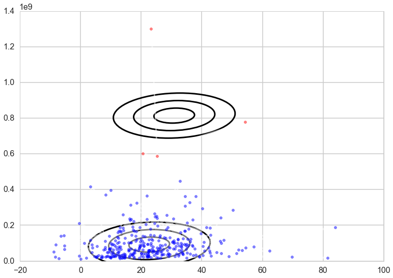

```python
plt.figure()
ax=plt.gca()
plot_ellipse(ax, gmm_means[0], gmm_covar, 'k')
plot_ellipse(ax, gmm_means[1], gmm_covar, 'k')
gmm_labels=clfgmm.predict(Xall)
for k, col in zip(range(n_clusters), ['blue','red']):
    my_members = gmm_labels == k
    ax.plot(Xall[my_members, 0], Xall[my_members, 1], 'w',
            markerfacecolor=col, marker='.', alpha=0.5)
```

This gives us a good approximation of two distinct clusters in our data. Basically, the movies that make more than 500 million dollars in total adjusted gross belongs to the red cluster, and the rest (which are the signifcant majority of the movies) belong to the blue cluster, so we should take this into account when doing further analysis.

Let's try to see if we would get a better result with 3 clusters:

```
GMM(covariance_type='tied', init_params='wmc', min_covar=0.001,
  n_components=2, n_init=1, n_iter=100, params='wmc', random_state=None,
  thresh=None, tol=0.001)
[[  2.18593152e+01   7.36447081e+07]
 [  3.08921900e+01   8.14926414e+08]
 [  2.45745724e+01   1.36629515e+08]] [[  1.77916251e+02   7.15394460e+07]
 [  7.15394460e+07   6.26401705e+15]]
```

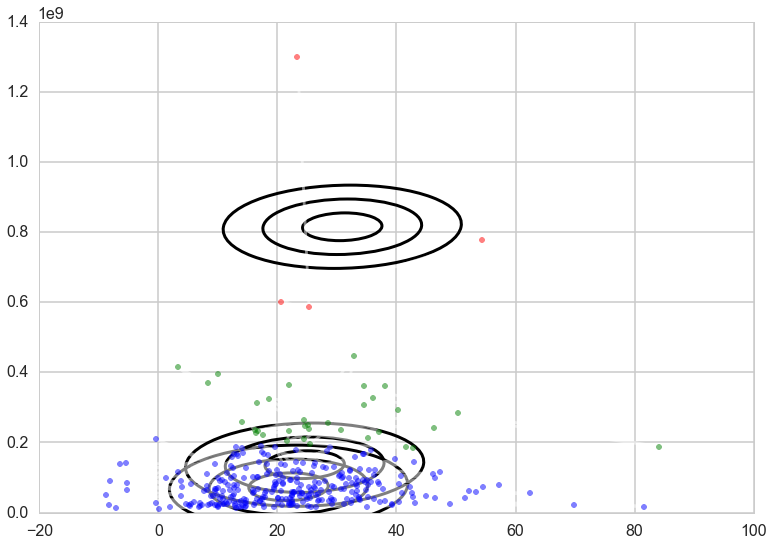

```python
n_clusters=3
clfgmm3 = GMM(n_components=n_clusters, covariance_type="tied")
clfgmm3.fit(Xall)
print clfgmm
gmm_means=clfgmm3.means_
gmm_covar=clfgmm3.covars_
print gmm_means, gmm_covar
plt.figure()
ax=plt.gca()
plot_ellipse(ax, gmm_means[0], gmm_covar, 'k')
plot_ellipse(ax, gmm_means[1], gmm_covar, 'k')
plot_ellipse(ax, gmm_means[2], gmm_covar, 'k')
gmm_labels=clfgmm3.predict(Xall)
for k, col in zip(range(n_clusters), ['blue','red', 'green']):
    my_members = gmm_labels == k
    ax.plot(Xall[my_members, 0], Xall[my_members, 1], 'w',
            markerfacecolor=col, marker='.', alpha=0.5)
```

Since there is so much overlap between the lower two clusters this time, we see that clustering into 2 groups is the better choice for our data. (We have also tried more clusters, but they similarly give worse results than the 2-clusters version)

# Bag of Words

### First import our dataset & dictionary

```python
# with open("IMDB_dftouse_dict.json", "r") as fd:
#     IMDB_dftouse_dict = json.load(fd)
# maas_IMDB = pd.DataFrame(IMDB_dftouse_dict)

with open("valence_df_dict.json", "r") as fp:
    valence_df_dict = json.load(fp)
maas_IMDB = pd.DataFrame(valence_df_dict)
```

```python
maas_IMDB.head()
```

|  | movie_id | movie_name | n_scorables | pct_scorables | positive | stars | text | url | valence_avg | valence_sum |
| --- | --- | --- | --- | --- | --- | --- | --- | --- | --- | --- |
| 0 | 10027 | Titanic | 120 | 0.666667 | 1 | 7 | Sure, Titanic was a good movie, the first time... | http://www.imdb.com/title/tt0120338/usercommen... | 0.479760 | 38.380826 |
| 1 | 10028 | Titanic | 65 | 0.538462 | 1 | 10 | When I saw this movie I was stunned by what a ... | http://www.imdb.com/title/tt0120338/usercommen... | 0.508760 | 17.806611 |
| 10 | 10037 | Titanic | 95 | 0.589474 | 1 | 9 | The ship may have sunk but the movie didn't!!!... | http://www.imdb.com/title/tt0120338/usercommen... | 0.700832 | 39.246578 |
| 100 | 11015 | Cliffhanger | 84 | 0.500000 | 1 | 9 | This movie is directed by Renny Harlin the fin... | http://www.imdb.com/title/tt0106582/usercommen... | 0.794284 | 33.359933 |
| 1000 | 10544 | The First Power | 194 | 0.618557 | 0 | 4 | When childhood memory tells you this was a sca... | http://www.imdb.com/title/tt0099578/usercommen... | 0.132427 | 15.891239 |

```python
maas_IMDB.shape
```

```
(4111, 10)
```

```python
with open("happiness.json", "r") as fp:
    happiness = json.load(fp)
```

```python
len(happiness)
```

```
10222
```

### Now we begin the Natural Language processing

This will take the form of a few steps.

1. Punctuation: we will remove punctuation from reviews, so that all words can be recognized
2. Lemmatization: we will reduce words to lemmas
3. Removing stop words: we will remove common words from our vocabulary, because they are unlikely to have been used to express sentiment -- which is what we are interested in

### Emulating HW5

1. For each review create a list of nouns, and a list of adjectives
2. For the nouns, perform LDA to separate them into 2 topics to see if there are 2 topics that are relevant i.e. actors vs. plot or whether it's sequel or a stand alone movie
3. Run the sentiment analysis on the adjectives **(N.B. At this point it is still not on an external dataset)**
4. Putting the topics and sentiment analysis together (marrying the nouns & the adjectives)
5. Estimate the overall mean for each movie on each topic

```python
from pattern.en import parse
from pattern.en import pprint
from pattern.vector import stem, PORTER, LEMMA
punctuation = list('.,;:!?()[]{}`''\"@#$^&*+-|=~_')
```

```python
from sklearn.feature_extraction import text
stopwords=text.ENGLISH_STOP_WORDS
```

### 1. For each review create a list of nouns, and a list of adjectives

```python
import re
regex1=re.compile(r"\.{2,}")
regex2=re.compile(r"\-{2,}")
```

```python
def get_parts(thetext):
    thetext=re.sub(regex1, ' ', thetext)
    thetext=re.sub(regex2, ' ', thetext)
    nouns=[]
    descriptives=[]
    for i,sentence in enumerate(parse(thetext, tokenize=True, lemmata=True).split()):
        nouns.append([])
        descriptives.append([])
        for token in sentence:
            #print token
            if len(token[4]) >0:
                if token[1] in ['JJ', 'JJR', 'JJS']:
                    if token[4] in stopwords or token[4][0] in punctuation or token[4][-1] in punctuation or len(token[4])==1:
                        continue
                    descriptives[i].append(token[4])
                elif token[1] in ['NN', 'NNS']:
                    if token[4] in stopwords or token[4][0] in punctuation or token[4][-1] in punctuation or len(token[4])==1:
                        continue
                    nouns[i].append(token[4])
    out=zip(nouns, descriptives)
    nouns2=[]
    descriptives2=[]
    for n,d in out:
        if len(n)!=0 and len(d)!=0:
            nouns2.append(n)
            descriptives2.append(d)
    return nouns2, descriptives2
```

```python
%%time
# review_parts = maas_IMDB.map(lambda x: get_parts(x.text))
review_parts = []
for index, row in maas_IMDB.iterrows():
    review_parts.append(get_parts(row.text))
```

[output not shown]

```python
review_parts[1]
```

```
([[u'movie', u'movie'],
  [u'movie', u'rating'],
  [u'movie', u'acting'],
  [u'job'],
  [u'<br', u'day'],
  [u'effect', u'more.<br', u'movie', u'rent']],
 [[u'great'],
  [u'star'],
  [u'superb'],
  [u'better'],
  [u'rainy'],
  [u'acting', u'special']])
```

### 2. For the nouns, perform LDA to separate them into 2 topics

```python
ldadata = [ele[0] for ele in review_parts]
```

```python
ldadata
```

[output not shown]

[output cut: 20452 more lines]

```
   u'company',
   u'convention'],
  [u'mood-creating', u'effect', u'throat', u'scene'],
  [u'character', u'end', u'romance', u'trick', u'home', u'smile', u'face'],
  [u'director',
   u'writer',
   u'audience',
   u'idiots??<br',
   u'movie',
   u'irritation'],
  [u'year', u'movie', u'rank', u'surprise']],
 [[u'story', u'guy', u'picture'],
  [u'story', u'female-hero', u'male-villain'],
  [u'person', u'face', u'face', u'inside']],
 ...]
```

```python
import itertools as IT
import collections

def flatten_iter(iterable, ltypes=collections.Iterable):
    remainder = iter(iterable)
    while True:
        first = next(remainder)
        if isinstance(first, ltypes) and not isinstance(first, basestring):
            remainder = IT.chain(first, remainder)
        else:
            yield first
```

```python
vocab_raw = list(flatten_iter(ldadata))
#removing duplicates
vocab_unique = []
for i in vocab_raw:
    if i not in vocab_unique:
        vocab_unique.append(i)
```

```python
vocab = {}
for i in range(len(vocab_unique)):
    vocab[vocab_unique[i]] = i

id2word = {}
for i in range(len(vocab_unique)):
    id2word[i] = vocab_unique[i]
```

```python
id2word[0], vocab.keys()[5], vocab[vocab.keys()[5]]
```

```
(u'sure', u'yellow', 5224)
```

```python
from collections import defaultdict

def auxillary_function(ldadata, vocab):
    d = defaultdict(int)
    for i in ldadata:
        index = vocab[i]
        d[index] += 1
    return d.items()
```

```python
all_reviews = []
for i in ldadata: # into a review
    this_review = []
    for j in i:
        for k in j:
            if k not in this_review:
                this_review.append(k)
    all_reviews.append(this_review)

corpus = []
for i in all_reviews:
    corpus.append(auxillary_function(i, vocab))
```

```python
corpus
```

[output not shown]

[output cut: 26430 more lines]

```
  (116, 1),
  (3190, 1),
  (121, 1),
  (250, 1),
  (21, 1),
  (2453, 1)],
 [(36, 1),
  (73, 1),
  (29, 1),
  (48, 1),
  (3063, 1),
  (5592, 1),
  (5593, 1),
  (61, 1)],
 ...]
```

```python
lda2 = gensim.models.ldamodel.LdaModel(corpus, num_topics=2,id2word = id2word,update_every=1,chunksize=20000,passes=1)
```

```
WARNING:gensim.models.ldamodel:too few updates, training might not converge; consider increasing the number of passes or iterations to improve accuracy
```

```python
lda2.print_topics()
```

```
[u'0.023*movie + 0.015*film + 0.012*time + 0.011*character + 0.008*scene + 0.008*story + 0.007*person + 0.007*thing + 0.006*plot + 0.006*actor',
 u'0.023*movie + 0.018*film + 0.011*character + 0.011*story + 0.009*time + 0.008*person + 0.008*way + 0.007*scene + 0.007*thing + 0.006*plot']
```

```python
for bow in corpus[0:900:15]:
    print bow
    print lda2.get_document_topics(bow)
    print " ".join([id2word[e[0]] for e in bow])
    print "=========================================="
```

```
[(0, 1), (1, 1), (2, 1), (3, 1), (4, 1), (5, 1), (6, 1), (7, 1), (8, 1), (9, 1), (10, 1), (11, 1), (12, 1), (13, 1), (14, 1), (15, 1), (16, 1), (17, 1), (18, 1), (19, 1), (20, 1), (21, 1)]
[(0, 0.85544771338087922), (1, 0.14455228661912081)]
sure movie time opinion film change ooh thinking d**n ship acting oscar eye character performance hand director magnitude lesson love-story filmmaker romance
==========================================
[(1, 1), (4, 1), (342, 1), (135, 1), (267, 1), (12, 1), (13, 1), (15, 1), (24, 1), (150, 1), (151, 1), (280, 1), (26, 1), (346, 1), (176, 1), (214, 1), (304, 1), (294, 1), (295, 1), (296, 1), (297, 1), (298, 1), (299, 1), (300, 1), (301, 1), (302, 1), (303, 1), (48, 1), (305, 1), (306, 1), (307, 1),…
[(0, 0.038067869871107787), (1, 0.96193213012889212)]
movie film piece ray book eye character hand <br plot line aspect effect dredge fact audience alien comment science fiction movie-goer history genre height author critic gun story pre-pubescent teenager today basement thought provoking boundary condition sake record computer graphic sequence emperor…
==========================================
[(440, 1), (21, 1), (511, 1)]
[(0, 0.49407476905169068), (1, 0.50592523094830932)]
it.<br romance purpose
==========================================
[(1, 1), (262, 1), (649, 1), (651, 1), (652, 1), (653, 1), (654, 1), (655, 1), (656, 1), (657, 1), (658, 1), (659, 1), (660, 1), (34, 1), (560, 1), (564, 1), (565, 1), (567, 1), (440, 1), (327, 1), (584, 1), (204, 1), (589, 1), (602, 1), (93, 1), (613, 1), (234, 1), (109, 1), (499, 1), (117, 1), (63…
[(0, 0.035310471773140145), (1, 0.96468952822685983)]
movie minute waste wasting summary hair guess shear nba hair.<br college laugh.<br wishes.<br friend shaq boom box boy it.<br skill rapping need wish life kid player money beer hour comedy ghetto
==========================================
[(1, 1), (4, 1), (13, 1), (14, 1), (557, 1), (20, 1), (30, 1), (800, 1), (801, 1), (802, 1), (803, 1), (804, 1), (805, 1), (806, 1), (807, 1), (808, 1), (809, 1), (810, 1), (811, 1), (812, 1), (813, 1), (814, 1), (815, 1), (48, 1), (817, 1), (818, 1), (819, 1), (820, 1), (821, 1), (822, 1), (823, 1)…
[(0, 0.9311292126315418), (1, 0.068870787368458239)]
movie film character performance music filmmaker scene magnolia wall canvas shrieking twit regret guilt pain writing ball mess.<br match digression sin tableaus fate story believer puppeteer string fable display form convergence wave spread absolution field cadre sequence genius circumstance person …
==========================================
[(640, 1), (36, 1), (940, 1), (941, 1), (942, 1), (943, 1), (602, 1)]
[(0, 0.91172778132813281), (1, 0.088272218671867228)]
sore face comedy.man organ leg makeup life
==========================================
[(128, 1), (1, 1), (2, 1), (10, 1), (529, 1), (23, 1), (29, 1), (709, 1), (176, 1), (36, 1), (173, 1), (48, 1), (50, 1), (1097, 1), (439, 1), (443, 1), (60, 1), (573, 1), (1087, 1), (1088, 1), (1089, 1), (1090, 1), (1091, 1), (1092, 1), (1093, 1), (1094, 1), (1095, 1), (1096, 1), (73, 1), (330, 1), …
[(0, 0.59783964882318297), (1, 0.40216035117681692)]
way movie time acting bit job picture version fact face role story actor view wife past man reason anger hype complaint american hardship period masterpiece.<br saint infidelity aggression person point assumption up.<br attitude interpretation community best persona cast actress
==========================================
[(1, 1), (2, 1), (262, 1), (7, 1), (10, 1), (13, 1), (142, 1), (527, 1), (1179, 1), (1180, 1), (283, 1), (169, 1), (50, 1), (180, 1), (60, 1), (61, 1), (77, 1), (1237, 1), (1238, 1), (1239, 1), (1240, 1), (1241, 1), (1242, 1), (1243, 1), (1244, 1), (1245, 1), (1246, 1), (1247, 1), (1248, 1), (1249, …
[(0, 0.97722948789773501), (1, 0.022770512102265019)]
movie time minute thinking acting character cliché that.<br friar wrestler direction year actor moment man guy script recess jack whale hammin misfire department.<br naff aneurism painful.<br remember pap plop to.<br total dream load reason
==========================================
[(4, 1), (198, 1), (73, 1), (1362, 1), (530, 1), (759, 1), (315, 1), (1343, 1)]
[(0, 0.27002312892601427), (1, 0.72997687107398579)]
film set person use focus game computer location
==========================================
[(1, 1), (4, 1), (10, 1), (13, 1), (1552, 1), (1557, 1), (1558, 1), (1559, 1), (1560, 1), (1561, 1), (1434, 1), (1563, 1), (1564, 1), (1562, 1), (30, 1), (1567, 1), (1568, 1), (1569, 1), (1570, 1), (1187, 1), (1193, 1), (1565, 1), (307, 1), (1566, 1), (182, 1), (1206, 1), (73, 1), (459, 1), (80, 1),…
[(0, 0.9211126005920679), (1, 0.078887399407932143)]
movie film acting character passion coward commitment show.<br wedding potato escape joy consequence etc.).<br scene criticism cynicism examination window finance heart actions.<br today shoddiness thing lack person turn twist failure society foot remorse suspense comedy romance
==========================================
```

[output cut: 185 more lines]

```
[(0, 0.35451524219470437), (1, 0.64548475780529568)]
film connection performance folk heart entertaining man
==========================================
[(96, 1), (896, 1), (578, 1), (33, 1), (3271, 1), (1193, 1), (128, 1), (4939, 1), (876, 1), (147, 1), (436, 1), (5143, 1), (218, 1), (1788, 1), (2554, 1)]
[(0, 0.9461130857660528), (1, 0.053886914233947168)]
scenario enjoy casting family chocolate heart way cup expression laugh weekend sip respect presence honey
==========================================
[(128, 1), (2944, 1), (899, 1), (4, 1), (3462, 1), (12, 1), (13, 1), (910, 1), (2072, 1), (3859, 1), (24, 1), (25, 1), (1266, 1), (175, 1), (176, 1), (946, 1), (243, 1), (446, 1), (182, 1), (439, 1), (440, 1), (3897, 1), (58, 1), (60, 1), (5181, 1), (5182, 1), (5183, 1), (71, 1), (3018, 1), (459, 1)…
[(0, 0.94387366385809401), (1, 0.056126336141905916)]
way wheel blood film consciousness eye character daughter hollywood mirror <br day atmosphere air fact taste mouth night thing wife it.<br path cold man affliction pre-pulp actioner memory photography turn car feel setup edge assassin comeback nemesis concept bit dream effort finger sidekick writer …
==========================================
[(1, 1), (2051, 1), (4, 1), (1797, 1), (385, 1), (2284, 1), (1035, 1), (140, 1), (269, 1), (529, 1), (2322, 1), (4372, 1), (150, 1), (3096, 1), (2586, 1), (1308, 1), (30, 1), (2565, 1), (1371, 1), (932, 1), (3367, 1), (169, 1), (5214, 1), (173, 1), (180, 1), (821, 1), (54, 1), (55, 1), (698, 1), (61…
[(0, 0.56503294070605592), (1, 0.43496705929394408)]
movie liner film violence spite revenge formula sense protagonist bit cigarette station plot grab corpse screen.<br scene echo physics hero break year pyrotechnic role moment display place action edge guy shootout scenario set person villain hint sarcasm heroine hall explosion piece aspect power cro…
==========================================
```

It looks like **topic 2** is about the external factors of a movie -- who the actors are and how production went, and **topic 1** is about the intrinsic factors of a movie -- the character development and plot. Examples:

[output not shown]

### 3. Run the sentiment analysis on the adjectives

```python
nbdata = [ele[1] for ele in review_parts]
```

[output not shown]

```python
adj_raw = list(flatten_iter(nbdata))
#removinc duplicates
adj_unique = []
for i in adj_raw:
    if i not in adj_unique:
        adj_unique.append(i)
```

[output not shown]

```python
adjvocab = {}
for i in range(len(adj_unique)):
    adjvocab[adj_unique[i]] = i
```

```python
adjvocab['great']
```

```
7
```

```python
len(adjvocab)
```

```
7335
```

```python
import itertools
Xarray = []
for i in nbdata: # into a review
    Xarraypre = " ".join(list(itertools.chain.from_iterable(i)))
    Xarray.append(Xarraypre)
```

Let's explore how many of our movies made gross sales above average, and how many had a value below average

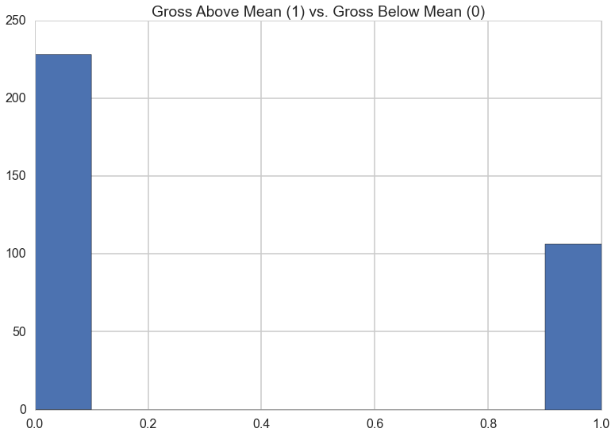

```python
plt.hist(dftouse.adj_gross_bin)
plt.title("Gross Above Mean (1) vs. Gross Below Mean (0)")
```

Turns out we have more movies below the mean than above, which makes a lot of sense, since there are only very few blockbusters, and they bring the mean to a higher value than it would have been without them.

```python
# making the response array based off of the sentiment dictionary 'happiness' there is valence_avg and valence_sum
resparray = []
for index, row in maas_IMDB.iterrows():
    if row.valence_avg > 0: # need to make it binomial because that's how the calibration/cv score works
        resparray.append(1)
    else:
        resparray.append(0)
```

```python
print  len(Xarray), len(resparray)
print Xarray[0]
```

```
4111 4111
good second love-story romantic second annoying impressive bad great glad half-good suprised worst wonderful talented crummy single possible mere
```

```python
from sklearn.cross_validation import train_test_split
itrain, itest = train_test_split(xrange(len(Xarray)), train_size=0.7)
mask=np.ones(len(Xarray), dtype='int')
mask[itrain]=1
mask[itest]=0
mask = (mask==1)
```

```python
X=np.array(Xarray)
y=np.array(resparray)
```

```python
y
```

```
array([1, 1, 1, ..., 1, 0, 1])
```

```python
def make_xy(X_col, y_col, vectorizer):
    X = vectorizer.fit_transform(X_col)
    y = y_col
    return X, y
```

```python
"""
Function
--------
log_likelihood

Compute the log likelihood of a dataset according to
a Naive Bayes classifier.
The Log Likelihood is defined by

L = Sum_positive(logP(positive)) + Sum_negative(logP(negative))

Where Sum_positive indicates a sum over all positive reviews,
and Sum_negative indicates a sum over negative reviews

Parameters
----------
clf : Naive Bayes classifier
x : (nexample, nfeature) array
    The input data
y : (nexample) integer array
    Whether each review is positive
"""
def log_likelihood(clf, x, y):
    prob = clf.predict_log_proba(x)
    neg = y == 0
    pos = ~neg
    return prob[neg, 0].sum() + prob[pos, 1].sum()
```

```python
from sklearn.cross_validation import KFold

def cv_score(clf, x, y, score_func, nfold=5):
    """
    Uses 5-fold cross validation to estimate a score of a classifier

    Inputs
    ------
    clf : Classifier object
    x : Input feature vector
    y : Input class labels
    score_func : Function like log_likelihood, that takes (clf, x, y) as input,
                 and returns a score

    Returns
    -------
    The average score obtained by splitting (x, y) into 5 folds of training and
    test sets, fitting on the training set, and evaluating score_func on the test set

    Examples
    cv_score(clf, x, y, log_likelihood)
    """
    result = 0
    for train, test in KFold(y.size, nfold): # split data into train/test groups, 5 times
        clf.fit(x[train], y[train]) # fit
        result += score_func(clf, x[test], y[test]) # evaluate score function on held-out data
    return result / nfold # average
```

```python
def calibration_plot(clf, xtest, ytest):
    prob = clf.predict_proba(xtest)[:, 1]
    outcome = ytest
    data = pd.DataFrame(dict(prob=prob, outcome=outcome))

    #group outcomes into bins of similar probability
    bins = np.linspace(0, 1, 20)
    cuts = pd.cut(prob, bins)
    binwidth = bins[1] - bins[0]

    #freshness ratio and number of examples in each bin
    cal = data.groupby(cuts).outcome.agg(['mean', 'count'])
    cal['pmid'] = (bins[:-1] + bins[1:]) / 2
    cal['sig'] = np.sqrt(cal.pmid * (1 - cal.pmid) / cal['count'])

    #the calibration plot
    ax = plt.subplot2grid((3, 1), (0, 0), rowspan=2)
    p = plt.errorbar(cal.pmid, cal['mean'], cal['sig'])
    plt.plot(cal.pmid, cal.pmid, linestyle='--', lw=1, color='k')
    plt.ylabel("Empirical P(+)")

    #the distribution of P(+)
    ax = plt.subplot2grid((3, 1), (2, 0), sharex=ax)

    plt.bar(left=cal.pmid - binwidth / 2, height=cal['count'],
            width=.95 * (bins[1] - bins[0]),
            fc=p[0].get_color())

    plt.xlabel("Predicted P(+)")
    plt.ylabel("Number")
```

```python
from sklearn.feature_extraction.text import CountVectorizer
from sklearn.naive_bayes import MultinomialNB
```

```python
#the grid of parameters to search over
alphas = [0, .1, 1, 5, 10, 50]
min_dfs = [1e-5, 1e-4, 1e-3, 1e-2, 1e-1]

#Find the best value for alpha and min_df, and the best classifier
best_alpha = None
best_min_df = None
maxscore = -np.inf

for alpha in alphas:
    for min_df in min_dfs:
        vectorizer = CountVectorizer(vocabulary =adjvocab, min_df = min_df)
        Xthis, Ythis = make_xy(X[mask], y[mask], vectorizer)
        clf = MultinomialNB(alpha=alpha)
        cvscore = cv_score(clf, Xthis, Ythis, log_likelihood)
        if cvscore > maxscore:
            maxscore = cvscore
            best_alpha, best_min_df = alpha, min_df
```

```python
print "alpha: %f" % best_alpha
print "min_df: %f" % best_min_df
```

```
alpha: 0.100000
min_df: 0.000010
```

```
Accuracy on training data: 0.97
Accuracy on test data:     0.91
```

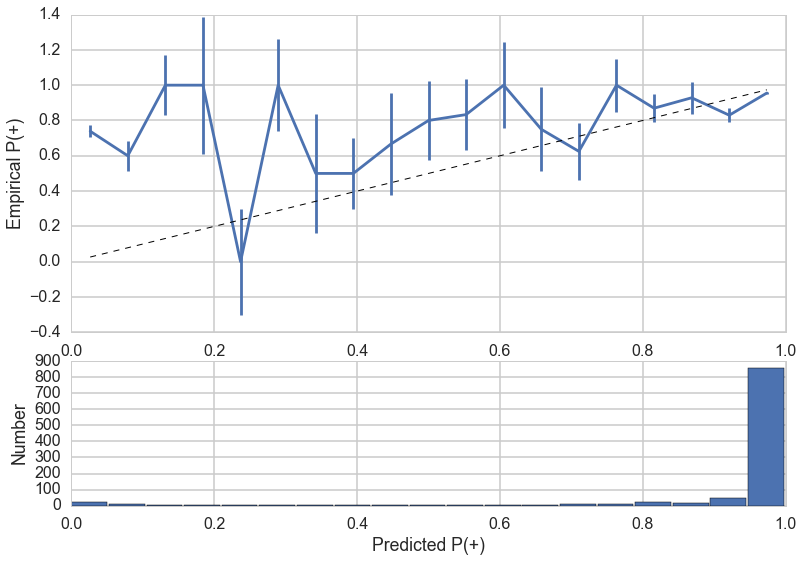

```python
vectorizer = CountVectorizer(vocabulary =adjvocab, min_df=best_min_df)
Xnew, Ynew = make_xy(X,y, vectorizer)
xtrain, xtest, ytrain, ytest = train_test_split(Xnew, Ynew)
clf = MultinomialNB(alpha=best_alpha).fit(xtrain, ytrain)

training_accuracy = clf.score(xtrain, ytrain)
test_accuracy = clf.score(xtest, ytest)

print "Accuracy on training data: %0.2f" % (training_accuracy)
print "Accuracy on test data:     %0.2f" % (test_accuracy)

calibration_plot(clf, xtest, ytest)
```

### 4. Putting the topics and sentiment analyses together

```python
vectorizer_alladj = CountVectorizer(min_df=best_min_df,vocabulary = adjvocab)
X_alladj, Y_alladj = make_xy(X[mask],y[mask], vectorizer_alladj)
clf_alladj = MultinomialNB(alpha=best_alpha).fit(X_alladj, Y_alladj)

logpositives = dict(zip(vectorizer_alladj.get_feature_names(),clf_alladj.feature_log_prob_[0]))
lognegatives = dict(zip(vectorizer_alladj.get_feature_names(),clf_alladj.feature_log_prob_[1]))
```

```python
def calc_pplus(adjlist, lp, ln, pp,pn):
    sgivenpos = 0
    sgivenneg = 0
    for adj in adjlist:
        sgivenpos += lp[adj]
        sgivenneg += ln[adj]
    return(np.exp(sgivenpos)*pp)/(np.exp(sgivenpos)*pp + np.exp(sgivenneg)*pn)
```

```python
reviews=[]
for index, row in maas_IMDB.iterrows():
    reviews.append(row.movie_id)
```

```python
# reviews
```

```python
len(review_parts),len(reviews)
```

```
(4111, 4111)
```

```python
def choose_topic(ldamodel, bow):
    tee = lda2.get_document_topics(bow)
    if len(tee)==2:
        t1,t2=tee
        if t2[1] >= t1[1]:#get higher probability topic
            topicis=t2[0]
        else:
            topicis=t1[0]
    elif len(tee)==1:#if only one was provided its very high probability. Take it
        teetuple=tee[0]
        topicis=teetuple[0]
    return topicis
```

```python
priorp = np.mean(resparray)
priorn = 1 - priorp
priorp, priorn
```

```
(0.92897105327171003, 0.071028946728289966)
```

```python
counter=0
reviewdict={}
for i, rid in enumerate(reviews):
    rlist=[]
    nlist, alist = review_parts[i]
    ln=len(nlist)
    localbow=corpus[counter:counter+ln]
    for bow, adj, noun in zip(localbow, alist, nlist):
        doc=" ".join([id2word[e[0]] for e in bow])
        pplus=calc_pplus(adj, logpositives, lognegatives, priorp, priorn)
        topicis=choose_topic(lda2, bow)
        ldict={"topic": topicis, 'pplus':pplus}
        rlist.append(ldict)
    reviewdict[rid]=rlist
    counter=counter+ln
```

```python
list_of_dicts=[]
for index, row in maas_IMDB.iterrows():
    revs=reviewdict[row.movie_id]
    for r in revs:
        r2=r.copy()
        r2['movie_id']=row.movie_name
        r2['url']=row.url
        r2['review_id']=row.movie_id
        r2['stars']=row.stars
        r2['valence_avg']=row.valence_avg
        r2['valence_sum']=row.valence_sum
        list_of_dicts.append(r2)
```

```python
completedf=pd.DataFrame(list_of_dicts)
completedf.head()
```

|  | movie_id | pplus | review_id | stars | topic | url | valence_avg | valence_sum |
| --- | --- | --- | --- | --- | --- | --- | --- | --- |
| 0 | Titanic | 0.807193 | 10027 | 7 | 0 | http://www.imdb.com/title/tt0120338/usercommen... | 0.47976 | 38.380826 |
| 1 | Titanic | 0.935017 | 10027 | 7 | 1 | http://www.imdb.com/title/tt0120338/usercommen... | 0.47976 | 38.380826 |
| 2 | Titanic | 0.891101 | 10027 | 7 | 0 | http://www.imdb.com/title/tt0120338/usercommen... | 0.47976 | 38.380826 |
| 3 | Titanic | 0.182409 | 10027 | 7 | 0 | http://www.imdb.com/title/tt0120338/usercommen... | 0.47976 | 38.380826 |
| 4 | Titanic | 0.828186 | 10027 | 7 | 0 | http://www.imdb.com/title/tt0120338/usercommen... | 0.47976 | 38.380826 |

```python
completedf.shape
```

```
(2815, 8)
```

### 5. Estimate the overall mean for each movie on each topic

```python
def get_stats(group):
    min_pplus = group.pplus.min()
    max_pplus = group.pplus.max()
    rid = group.movie_id.unique()
    valence_avg = group.valence_avg.mean()
    valence_sum = group.valence_sum.mean()
    count = group.topic.count()
    if count == 1:
        varj = 0
    else:
        varj = group.pplus.var(ddof=1)
    mean_pplus = group.pplus.mean()
    stars = group.stars.mean()
    return pd.DataFrame({'min': min_pplus, 'max':max_pplus ,'valence_avg': valence_avg,'valence_sum':valence_sum,
                         'count': count,'var': varj, 'mean': mean_pplus, 'stars': stars}, index=rid)
```

```python
%%time
dftouse=completedf.groupby(['review_id', 'topic']).apply(get_stats).reset_index()
```

[output not shown]

[output cut: 47 more lines]

[output not shown]

```python
print dftouse.shape
dftouse.head()
```

```
(699, 11)
```

|  | review_id | topic | level_2 | count | max | mean | min | stars | valence_avg | valence_sum | var |
| --- | --- | --- | --- | --- | --- | --- | --- | --- | --- | --- | --- |
| 0 | 7455 | 0 | Corky Romano | 1 | 0.951056 | 0.951056 | 0.951056 | 3 | 0.040475 | 0.566644 | 0.000000 |
| 1 | 7455 | 1 | Corky Romano | 1 | 0.935816 | 0.935816 | 0.935816 | 3 | 0.040475 | 0.566644 | 0.000000 |
| 2 | 7456 | 0 | Corky Romano | 6 | 0.973302 | 0.758510 | 0.044043 | 2 | 0.196665 | 8.259933 | 0.125997 |
| 3 | 7457 | 0 | Corky Romano | 4 | 0.946638 | 0.844130 | 0.690218 | 4 | 0.218332 | 9.169933 | 0.013005 |
| 4 | 7457 | 1 | Corky Romano | 1 | 0.968079 | 0.968079 | 0.968079 | 4 | 0.218332 | 9.169933 | 0.000000 |

```python
dftouse[dftouse.review_id==10037]
```

|  | review_id | topic | level_2 | count | max | mean | min | stars | valence_avg | valence_sum | var |
| --- | --- | --- | --- | --- | --- | --- | --- | --- | --- | --- | --- |
| 264 | 10037 | 0 | Titanic | 5 | 0.876692 | 0.635052 | 0.052174 | 9 | 0.700832 | 39.246578 | 0.124518 |
| 265 | 10037 | 1 | Titanic | 1 | 0.674595 | 0.674595 | 0.674595 | 9 | 0.700832 | 39.246578 | 0.000000 |

### Using the NLTK library

```python
! pip install nltk
```

```python
import nltk
from nltk.corpus import sentiwordnet as swn
```

```python
happy = swn.senti_synset('happy.n.03')
print(happy)
```

[output not shown]

```python
type(swn)
```

```
nltk.corpus.util.LazyCorpusLoader
```

### Classification

#### Let's try classifying some stuff!

Here, we attempt to see if we can get better predictive power using some of the classifiers we learnt in class.

```python
from sklearn.svm import LinearSVC
from sklearn.grid_search import GridSearchCV
from sklearn.cross_validation import train_test_split
from sklearn.metrics import confusion_matrix
from matplotlib.colors import ListedColormap
from sklearn.linear_model import LogisticRegression


def cv_optimize(clf, parameters, X, y, n_jobs=1, n_folds=5, score_func=None):
    if score_func:
        gs = GridSearchCV(clf, param_grid=parameters, cv=n_folds, n_jobs=n_jobs, scoring=score_func)
    else:
        gs = GridSearchCV(clf, param_grid=parameters, n_jobs=n_jobs, cv=n_folds)
    gs.fit(X, y)
    print "BEST", gs.best_params_, gs.best_score_, gs.grid_scores_
    best = gs.best_estimator_
    return best
def do_classify(clf, parameters, indf, featurenames, targetname, target1val, mask=None, reuse_split=None, score_func=None, n_folds=5, n_jobs=1):
    subdf=indf[featurenames]
    X=subdf.values
    y=(indf[targetname].values==target1val)*1
    if mask !=None:
        print "using mask"
        Xtrain, Xtest, ytrain, ytest = X[mask], X[~mask], y[mask], y[~mask]
    if reuse_split !=None:
        print "using reuse split"
        Xtrain, Xtest, ytrain, ytest = reuse_split['Xtrain'], reuse_split['Xtest'], reuse_split['ytrain'], reuse_split['ytest']
    if parameters:
        clf = cv_optimize(clf, parameters, Xtrain, ytrain, n_jobs=n_jobs, n_folds=n_folds, score_func=score_func)
    clf=clf.fit(Xtrain, ytrain)
    training_accuracy = clf.score(Xtrain, ytrain)
    test_accuracy = clf.score(Xtest, ytest)
    print "############# based on standard predict ################"
    print "Accuracy on training data: %0.2f" % (training_accuracy)
    print "Accuracy on test data:     %0.2f" % (test_accuracy)
    print confusion_matrix(ytest, clf.predict(Xtest))
    print "########################################################"
    return clf, Xtrain, ytrain, Xtest, ytest
```

```python
cmap_light = ListedColormap(['#FFAAAA', '#AAFFAA', '#AAAAFF'])
cmap_bold = ListedColormap(['#FF0000', '#00FF00', '#0000FF'])
cm = plt.cm.RdBu
cm_bright = ListedColormap(['#FF0000', '#0000FF'])

def points_plot(ax, Xtr, Xte, ytr, yte, clf, mesh=True, colorscale=cmap_light, cdiscrete=cmap_bold, alpha=0.3, psize=10, zfunc=False):
    h = .02
    X=np.concatenate((Xtr, Xte))
    x_min, x_max = X[:, 0].min() - .5, X[:, 0].max() + .5
    y_min, y_max = X[:, 1].min() - .5, X[:, 1].max() + .5
    xx, yy = np.meshgrid(np.linspace(x_min, x_max, 100),
                         np.linspace(y_min, y_max, 100))

    #plt.figure(figsize=(10,6))
    if mesh:
        if zfunc:
            p0 = clf.predict_proba(np.c_[xx.ravel(), yy.ravel()])[:, 0]
            p1 = clf.predict_proba(np.c_[xx.ravel(), yy.ravel()])[:, 1]
            Z=zfunc(p0, p1)
        else:
            Z = clf.predict(np.c_[xx.ravel(), yy.ravel()])
        Z = Z.reshape(xx.shape)
        plt.pcolormesh(xx, yy, Z, cmap=cmap_light, alpha=alpha, axes=ax)
    ax.scatter(Xtr[:, 0], Xtr[:, 1], c=ytr-1, cmap=cmap_bold, s=psize, alpha=alpha,edgecolor="k")
    # and testing points
    yact=clf.predict(Xte)
    ax.scatter(Xte[:, 0], Xte[:, 1], c=yte-1, cmap=cmap_bold, alpha=alpha, marker="s", s=psize+10)
    ax.set_xlim(xx.min(), xx.max())
    ax.set_ylim(yy.min(), yy.max())
    return ax,xx,yy
```

```python
def points_plot_prob(ax, Xtr, Xte, ytr, yte, clf, colorscale=cmap_light, cdiscrete=cmap_bold, ccolor=cm, psize=10, alpha=0.1, prob=True):
    ax,xx,yy = points_plot(ax, Xtr, Xte, ytr, yte, clf, mesh=False, colorscale=colorscale, cdiscrete=cdiscrete, psize=psize, alpha=alpha)
    if prob:
        Z = clf.predict_proba(np.c_[xx.ravel(), yy.ravel()])[:, 1]
    else:
        Z = clf.decision_function(np.c_[xx.ravel(), yy.ravel()])
    Z = Z.reshape(xx.shape)
    plt.contourf(xx, yy, Z, cmap=ccolor, alpha=.2, axes=ax)
    cs2 = plt.contour(xx, yy, Z, cmap=ccolor, alpha=.6, axes=ax)
    plt.clabel(cs2, fmt = '%2.1f', colors = 'k', fontsize=14, axes=ax)
    return ax
```

```python
dftouse.head()
```

|  | abs_valence_avg | adj_gross | adj_gross_bin | adj_opening_gross | adj_opening_gross_bin | n_scorables | pct_scorables | positive | ranking | review_count | star_avg | total_theaters | valence_avg | valence_sum | year |
| --- | --- | --- | --- | --- | --- | --- | --- | --- | --- | --- | --- | --- | --- | --- | --- |
| 102 Dalmatians | 0.435028 | 9.300887e+07 | 0 | 27619626.583993 | 1 | 95.20 | 0.554479 | 1 | 38 | 10 | 8.30 | 2704 | 0.764973 | 34.991588 | 2000 |
| 13 Going on 30 | 0.075914 | 8.720185e+07 | 0 | 32079616.730188 | 1 | 94.75 | 0.614963 | 0 | 56 | 4 | 2.50 | 3453 | 0.344982 | 19.569669 | 2004 |
| 3 Ninjas | 0.337339 | 3.282516e+07 | 0 | 6665611.384807 | 0 | 107.25 | 0.647320 | 0 | 44 | 4 | 1.25 | 1954 | 0.235649 | 26.775243 | 1992 |
| 50 First Dates | 0.060371 | 1.842231e+08 | 1 | 60721350.083526 | 1 | 60.00 | 0.600000 | 0 | 15 | 1 | 3.00 | 3612 | 0.390316 | 14.051372 | 2004 |
| 8MM | 0.388165 | 4.926479e+07 | 0 | 19151719.429485 | 0 | 241.00 | 0.626556 | 0 | 56 | 1 | 1.00 | 2370 | -0.058220 | -8.791192 | 1999 |

```
using mask
BEST {'C': 1e-09} 0.661616161616 [mean: 0.66162, std: 0.00665, params: {'C': 1e-09}, mean: 0.66162, std: 0.00665, params: {'C': 1e-08}, mean: 0.66162, std: 0.00665, params: {'C': 1e-06}, mean: 0.66162, std: 0.00665, params: {'C': 1e-05}, mean: 0.66162, std: 0.00665, params: {'C': 0.0001}, mean: 0.66…
############# based on standard predict ################
Accuracy on training data: 0.66
Accuracy on test data:     0.62
[[82  0]
 [51  0]]
########################################################
```

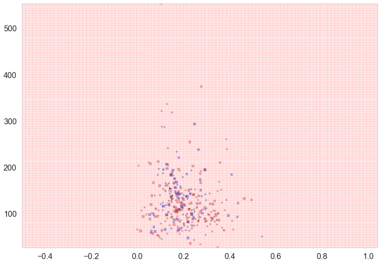

```python
itrain, itest = train_test_split(xrange(dftouse.shape[0]), train_size=0.6)
mask_classify=np.ones(dftouse.shape[0], dtype='int')
mask_classify[itrain]=1
mask_classify[itest]=0
mask_classify = (mask_classify==1)
mask_classify[:10]

Xnames = ['year','total_theaters' ,'star_avg','review_count','positive','n_scorables','pct_scorables','valence_avg']
two_features = ['abs_valence_avg','n_scorables']

clflog1 = LogisticRegression()
parameters_log = {"C": [0.000000001, 0.00000001, 0.000001, 0.00001, 0.0001, 0.001, 0.01, 0.1, 1, 10, 100,]}
clflog1, Xtrain, ytrain, Xtest, ytest=do_classify(clflog1, parameters_log, dftouse,
                                                 two_features,
                                                 'adj_opening_gross_bin', 1, mask=mask_classify)
Xtr=np.concatenate((Xtrain, Xtest))
plt.figure()
ax=plt.gca()
nonamebob = points_plot(ax, Xtrain, Xtest, ytrain, ytest, clflog1)
```

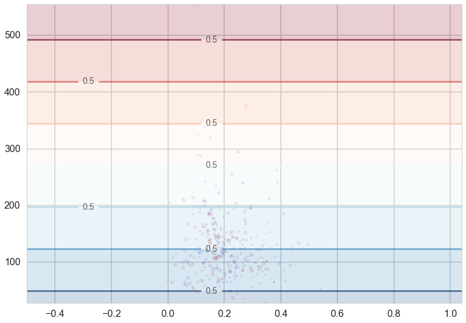

```python
plt.figure()
ax=plt.gca()
points_plot(ax, Xtrain, Xtest, ytrain, ytest, clflog1, mesh=False, alpha=0.001);
points_plot_prob(ax, Xtrain, Xtest, ytrain, ytest, clflog1);
```

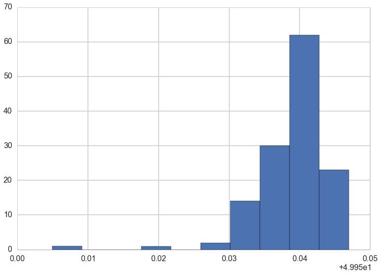

```python
plt.hist(clflog1.predict_proba(Xtest)[:,1]*100);
```

```python
clflog1.score(Xtest, ytest)
```

```
0.61654135338345861
```

```python
clflog2 = LogisticRegression()
clflog2, Xtrain, ytrain, Xtest, ytest=do_classify(clflog2, parameters_log, dftouse,
                                                 Xnames,
                                                 'adj_opening_gross_bin', 1, mask=mask_classify)
```

```
using mask
BEST {'C': 10} 0.893939393939 [mean: 0.66162, std: 0.00665, params: {'C': 1e-09}, mean: 0.66162, std: 0.00665, params: {'C': 1e-08}, mean: 0.86364, std: 0.04498, params: {'C': 1e-06}, mean: 0.87374, std: 0.03531, params: {'C': 1e-05}, mean: 0.87374, std: 0.03531, params: {'C': 0.0001}, mean: 0.87374…
############# based on standard predict ################
Accuracy on training data: 0.89
Accuracy on test data:     0.83
[[66 16]
 [ 7 44]]
########################################################
```

```
using mask
BEST {'C': 0.001} 0.661616161616 [mean: 0.66162, std: 0.00665, params: {'C': 0.001}, mean: 0.66162, std: 0.00665, params: {'C': 0.01}, mean: 0.66162, std: 0.00665, params: {'C': 0.1}, mean: 0.66162, std: 0.00665, params: {'C': 1}, mean: 0.66162, std: 0.00665, params: {'C': 10}, mean: 0.66162, std: 0…
############# based on standard predict ################
Accuracy on training data: 0.66
Accuracy on test data:     0.62
[[82  0]
 [51  0]]
########################################################
```

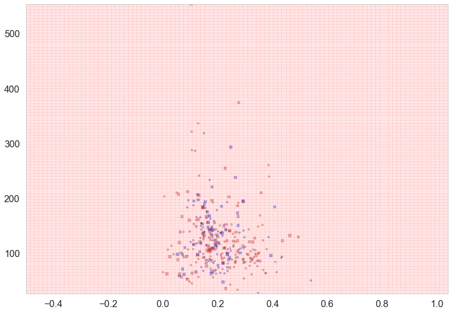

```python
from sklearn.svm import SVC
clfsvm1 = SVC(kernel="linear")
parameters_svc = {"C": [0.001, 0.01, 0.1, 1, 10, 100, 1000]}
clfsvm1, Xtrain, ytrain, Xtest, ytest=do_classify(clfsvm1, parameters_svc, dftouse,
                                                 two_features,
                                                 'adj_opening_gross_bin', 1, mask=mask_classify)
Xtr=np.concatenate((Xtrain, Xtest))
plt.figure()
ax=plt.gca()
points_plot(ax, Xtrain, Xtest, ytrain, ytest, clfsvm1);
```

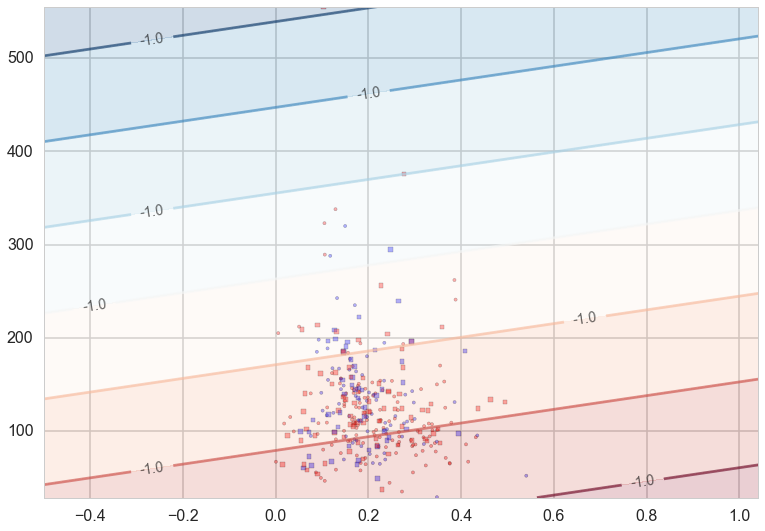

```python
plt.figure()
ax=plt.gca()
points_plot(ax, Xtrain, Xtest, ytrain, ytest, clfsvm1, mesh=False);
points_plot_prob(ax, Xtrain, Xtest, ytrain, ytest, clfsvm1, prob=False);
```

```python
#From Jake Vanderplas's ESAC notebook
def plot_svc_decision_function(clf, ax=None):
    """Plot the decision function for a 2D SVC"""
    if ax is None:
        ax = plt.gca()
    x = np.linspace(plt.xlim()[0], plt.xlim()[1], 30)
    y = np.linspace(plt.ylim()[0], plt.ylim()[1], 30)
    Y, X = np.meshgrid(y, x)
    P = np.zeros_like(X)
    for i, xi in enumerate(x):
        for j, yj in enumerate(y):
            P[i, j] = clf.decision_function([xi, yj])
    return ax.contour(X, Y, P, colors='k',
                      levels=[-1, 0, 1], alpha=0.5,
                      linestyles=['--', '-', '--'])
```

```
(125, 225)
```

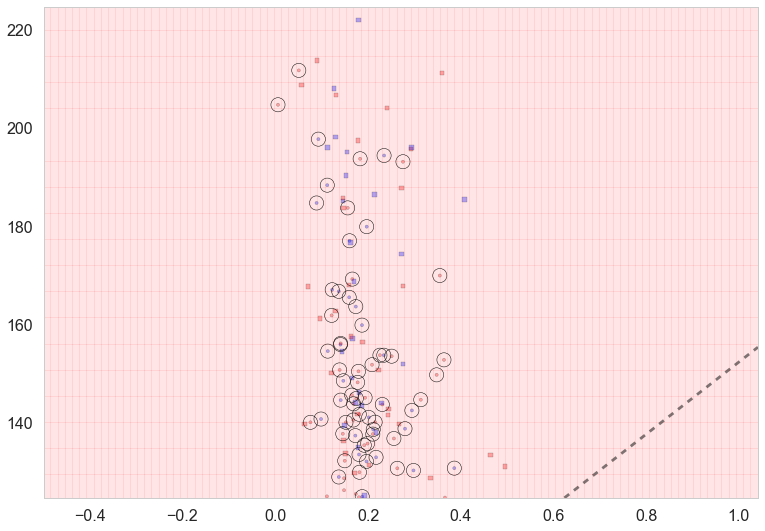

```python
plt.figure()
ax=plt.gca()
points_plot(ax, Xtrain, Xtest, ytrain, ytest, clfsvm1);
plot_svc_decision_function(clfsvm1, ax)
ax.scatter(clfsvm1.support_vectors_[:, 0], clfsvm1.support_vectors_[:, 1],s=200, facecolors='none')
plt.ylim([125,225])
```